# 의료 접근성이 건강 결과에 미치는 영향 분석

소득이 낮은 집단일수록 당뇨병에 더 많이 노출된다는 보도를 보고, 그 격차의 원인이 소득 그 자체가 아니라 의료 접근성 차이일 수 있다는 데 주목했다 — 소득이 낮아 정기검진·병원 방문 같은 의료 서비스에 접근하기 어려운 것이 건강 격차의 실질적 원인일 수 있다는 것이다. 그래서 이 분석은 소득이 아니라 **의료 접근성**을 핵심 변수로 놓고, 소득은 교란변수로 통제하면서 접근성이 건강 결과에 독립적인 영향을 미치는지를 확인한다.

BRFSS 2015 당뇨병 건강지표 데이터셋을 이용해 의료 접근성(`AnyHealthcare`, `NoDocbcCost`, `CholCheck`)이 건강 결과(`Diabetes_binary`, `GenHlth`, `PhysHlth`, `HighBP`, `HighChol`)에 미치는 영향을 분석한다.

소득(`Income`), 연령(`Age`), 교육수준(`Education`)을 교란변수로 통제하여 접근성 변수의 독립적 효과를 추정하는 것이 핵심 질문이다. 이 데이터셋을 고른 이유와 데이터 자체의 성격은 1절에서 자세히 다룬다.

**진행 순서**: 데이터 이해 → 데이터 전처리 → EDA → 교차분석·카이제곱검정 → 교란변수 선정 → 소득 층화분석 → 기초 모델링(로지스틱 회귀) → 예측 모델링 → 합성데이터 검증 → 종합 결론

```python
import pandas as pd
import numpy as np
import matplotlib.pyplot as plt
import seaborn as sns
from scipy.stats import chi2_contingency
import statsmodels.api as sm
import statsmodels.formula.api as smf

sns.set_theme(style="whitegrid")
plt.rcParams["font.family"] = "Malgun Gothic"
plt.rcParams["axes.unicode_minus"] = False

DATA_PATH = "../data/raw/diabetes_binary_health_indicators_BRFSS2015.csv"
df = pd.read_csv(DATA_PATH)
df.shape
```

```
(253680, 22)
```

## 1. 데이터 이해

### 이 데이터를 고른 이유

이 데이터셋에는 `AnyHealthcare`(의료 이용 수단 보유), `NoDocbcCost`(비용 때문에 병원 미방문 경험), `CholCheck`(정기검진 여부) 같은 **의료 접근성을 직접 측정하는 변수**가 포함돼 있다. 이런 변수를 가진 공개 데이터셋은 흔치 않아서, "의료 접근성이 건강 결과에 독립적인 영향을 미치는가"라는 질문을 실제 데이터로 검증해볼 수 있었다 — 데이터가 가진 이 특성이 이번 분석 주제를 고른 직접적인 이유다.

### 행과 컬럼

- **행 하나의 의미**: 2015년 미국 CDC의 BRFSS(Behavioral Risk Factor Surveillance System, 행동위험요인감시체계) 전화 설문에 응답한 성인 1명
- **기간과 범위**: 2015년 한 해, 미국 성인 253,680명
- **컬럼 구성**: 결과지표 1개(`Diabetes_binary`), 의료 접근성 3개, 만성질환·생활습관 지표 다수, 인구통계 4개(`Sex`, `Age`, `Education`, `Income`) — 전체 22개 컬럼의 의미와 코드는 `references/data_dictionary.md`에 정리했다.
- **출처와 저작권**: CDC BRFSS 원자료는 미국 연방정부 공공데이터로 저작권 제한 없이 공개돼 있다. 이 프로젝트에서 쓰는 CSV는 Kaggle에 [Diabetes Health Indicators Dataset](https://www.kaggle.com/datasets/alexteboul/diabetes-health-indicators-dataset)(Alex Teboul 재배포, **CC0: Public Domain** 라이선스)이라는 이름으로 재배포된 파생 버전이다.

## 2. 데이터 전처리

결측치, 중복행, 값 범위(코드북 대비 이상값), 연속형 변수의 이상치를 확인하고 분석에 쓸 변수들의 타입을 정리한다.

```python
# 결측치 / 중복행 확인
print("Missing values total:", df.isna().sum().sum())
print("Duplicate rows:", df.duplicated().sum())
df.info()
```

```
Missing values total: 0
Duplicate rows: 24206
<class 'pandas.DataFrame'>
RangeIndex: 253680 entries, 0 to 253679
Data columns (total 22 columns):
 #   Column                Non-Null Count   Dtype
---  ------                --------------   -----
 0   Diabetes_binary       253680 non-null  float64
 1   HighBP                253680 non-null  float64
 2   HighChol              253680 non-null  float64
 3   CholCheck             253680 non-null  float64
 4   BMI                   253680 non-null  float64
 5   Smoker                253680 non-null  float64
 6   Stroke                253680 non-null  float64
 7   HeartDiseaseorAttack  253680 non-null  float64
```

[output cut: 16 more lines]

**결측치·중복행 확인**: 결측치는 0건으로 없다. 반면 전체 253,680행 중 24,206행(9.5%)이 완전히 동일한 값 조합을 가진다. 모든 변수가 구간화된 범주형 코드이고 표본 크기가 크기 때문에, 서로 다른 응답자가 우연히 같은 코드 조합을 가질 가능성이 충분히 있다(데이터 입력 오류로 보기 어려움). 따라서 이번 분석에서는 중복행을 삭제하지 않고 전체 표본을 유지한다 — 다만 리포트의 한계(limitation)로 명시한다.

```python
# 코드북 대비 값 범위 점검 (모든 컬럼이 float이지만 실제로는 이진/순서형 코드)
for col in ["AnyHealthcare", "NoDocbcCost", "CholCheck", "Diabetes_binary"]:
    print(col, sorted(df[col].unique()))
for col in ["Income", "Education", "GenHlth", "Age"]:
    print(col, sorted(df[col].unique()))
```

```
AnyHealthcare [np.float64(0.0), np.float64(1.0)]
NoDocbcCost [np.float64(0.0), np.float64(1.0)]
CholCheck [np.float64(0.0), np.float64(1.0)]
Diabetes_binary [np.float64(0.0), np.float64(1.0)]
Income [np.float64(1.0), np.float64(2.0), np.float64(3.0), np.float64(4.0), np.float64(5.0), np.float64(6.0), np.float64(7.0), np.float64(8.0)]
Education [np.float64(1.0), np.float64(2.0), np.float64(3.0), np.float64(4.0), np.float64(5.0), np.float64(6.0)]
GenHlth [np.float64(1.0), np.float64(2.0), np.float64(3.0), np.float64(4.0), np.float64(5.0)]
Age [np.float64(1.0), np.float64(2.0), np.float64(3.0), np.float64(4.0), np.float64(5.0), np.float64(6.0), np.float64(7.0), np.float64(8.0), np.float64(9.0), np.float64(10.0), np.float64(11.0), np.float64(12.0), np.float64(13.0)]
```

**값 범위 점검 결과**: 모든 이진/순서형 변수의 값 범위는 코드북과 일치함을 확인했다 (`AnyHealthcare`, `NoDocbcCost`, `CholCheck`, `Diabetes_binary` ∈ {0,1}, `Income` 1~8, `Education` 1~6, `GenHlth` 1~5, `Age` 1~13 구간코드).

```
count    253680.000000
mean         28.382364
std           6.608694
min          12.000000
25%          24.000000
50%          27.000000
75%          31.000000
max          98.000000
Name: BMI, dtype: float64
IQR 기준 정상 범위: 13.5 ~ 41.5
이상치 비율: 3.88%
```

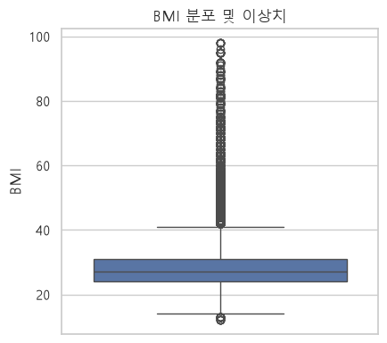

```python
# 연속형 변수(BMI) 이상치 점검 - 이 데이터셋에서 유일한 연속형 변수
print(df["BMI"].describe())

q1, q3 = df["BMI"].quantile([0.25, 0.75])
iqr = q3 - q1
lower, upper = q1 - 1.5 * iqr, q3 + 1.5 * iqr
outlier_ratio = ((df["BMI"] < lower) | (df["BMI"] > upper)).mean()
print("IQR 기준 정상 범위:", round(lower, 1), "~", round(upper, 1))
print(f"이상치 비율: {outlier_ratio:.2%}")

fig, ax = plt.subplots(figsize=(4.5, 4))
sns.boxplot(y=df["BMI"], ax=ax, color="#4C72B0")
ax.set_title("BMI 분포 및 이상치")
plt.tight_layout()
plt.show()
```

**이상치 처리 방침**: IQR 기준 정상 범위는 13.5~41.5이고 전체의 3.9%가 이 범위를 벗어난다. 최댓값 98은 병적 고도비만(BMI 98 ≈ 키 170cm에 체중 283kg)에 해당해 극단적이지만, BMI는 의학적으로 이론상 가능한 범위(대략 10~100)를 벗어나지 않고 자료형 오류(음수, 문자 혼입 등)도 없다. 실제로 존재할 수 있는 값이므로 삭제나 절단(capping) 없이 그대로 유지한다 — 다만 7.1절의 Box-Tidwell 검정에서 확인하듯 극단값이 있는 연속형 변수라 로지스틱 회귀의 선형성 가정에 영향을 줄 수 있다는 점은 별도로 점검한다.

```python
# 해석 편의를 위한 라벨 매핑 (BRFSS 2015 코드북 기준)
age_labels = {1: "18-24", 2: "25-29", 3: "30-34", 4: "35-39", 5: "40-44", 6: "45-49",
              7: "50-54", 8: "55-59", 9: "60-64", 10: "65-69", 11: "70-74", 12: "75-79", 13: "80+"}
income_labels = {1: "<10k", 2: "10-15k", 3: "15-20k", 4: "20-25k", 5: "25-35k",
                 6: "35-50k", 7: "50-75k", 8: "75k+"}
genhlth_labels = {1: "Excellent", 2: "Very good", 3: "Good", 4: "Fair", 5: "Poor"}

df_eda = df.copy()
df_eda["AgeGroup"] = df_eda["Age"].map(age_labels)
df_eda["IncomeGroup"] = df_eda["Income"].map(income_labels)
df_eda["GenHlthLabel"] = df_eda["GenHlth"].map(genhlth_labels)
df_eda["PoorGenHlth"] = (df_eda["GenHlth"] >= 4).astype(int)  # Fair/Poor = 1
df_eda.head()
```

|  | Diabetes_binary | HighBP | HighChol | CholCheck | BMI | Smoker | Stroke | HeartDiseaseorAttack | PhysActivity | Fruits | ... | PhysHlth | DiffWalk | Sex | Age | Education | Income | AgeGroup | IncomeGroup | GenHlthLabel | PoorGenHlth |
| --- | --- | --- | --- | --- | --- | --- | --- | --- | --- | --- | --- | --- | --- | --- | --- | --- | --- | --- | --- | --- | --- |
| 0 | 0.0 | 1.0 | 1.0 | 1.0 | 40.0 | 1.0 | 0.0 | 0.0 | 0.0 | 0.0 | ... | 15.0 | 1.0 | 0.0 | 9.0 | 4.0 | 3.0 | 60-64 | 15-20k | Poor | 1 |
| 1 | 0.0 | 0.0 | 0.0 | 0.0 | 25.0 | 1.0 | 0.0 | 0.0 | 1.0 | 0.0 | ... | 0.0 | 0.0 | 0.0 | 7.0 | 6.0 | 1.0 | 50-54 | <10k | Good | 0 |
| 2 | 0.0 | 1.0 | 1.0 | 1.0 | 28.0 | 0.0 | 0.0 | 0.0 | 0.0 | 1.0 | ... | 30.0 | 1.0 | 0.0 | 9.0 | 4.0 | 8.0 | 60-64 | 75k+ | Poor | 1 |
| 3 | 0.0 | 1.0 | 0.0 | 1.0 | 27.0 | 0.0 | 0.0 | 0.0 | 1.0 | 1.0 | ... | 0.0 | 0.0 | 0.0 | 11.0 | 3.0 | 6.0 | 70-74 | 35-50k | Very good | 0 |
| 4 | 0.0 | 1.0 | 1.0 | 1.0 | 24.0 | 0.0 | 0.0 | 0.0 | 1.0 | 1.0 | ... | 0.0 | 0.0 | 0.0 | 11.0 | 5.0 | 4.0 | 70-74 | 20-25k | Very good | 0 |

5 rows × 26 columns

해석 편의를 위해 코드북 기준으로 숫자 코드를 라벨로 매핑한다. 그 이유는 `Age`, `Income`, `GenHlth` 같은 변수가 원래 순서형 정수 코드라 그래프나 표에 그대로 쓰면 값의 의미를 매번 코드북과 대조해야 하기 때문이다. 같은 셀에서 `PoorGenHlth`라는 파생변수도 새로 정의하는데, `GenHlth`(1=Excellent ~ 5=Poor) 값이 4(Fair) 이상이면 1로 코딩해 `Diabetes_binary` 외에 주관적 건강상태 불량 여부를 나타내는 보조 결과지표로 4절과 7절에서 반복적으로 쓴다.

## 3. EDA

### 3.1 타깃 변수(`Diabetes_binary`) 분포와 클래스 불균형

본격적인 탐색에 앞서, 결과지표인 `Diabetes_binary`의 분포부터 확인한다. 이후 모든 모델링(오즈비 추정, 예측 모델링)에서 이 클래스 불균형을 고려해야 한다.

```
                  count   ratio
Diabetes_binary
0.0              218334  0.8607
1.0               35346  0.1393
```

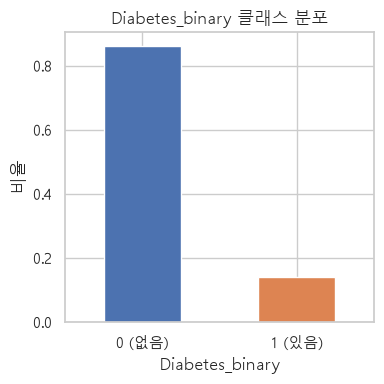

```python
diabetes_counts = df_eda["Diabetes_binary"].value_counts().sort_index()
diabetes_ratio = df_eda["Diabetes_binary"].value_counts(normalize=True).sort_index()
print(pd.DataFrame({"count": diabetes_counts, "ratio": diabetes_ratio.round(4)}))

fig, ax = plt.subplots(figsize=(4, 4))
diabetes_ratio.plot(kind="bar", ax=ax, color=["#4C72B0", "#DD8452"])
ax.set_xticklabels(["0 (없음)", "1 (있음)"], rotation=0)
ax.set_ylabel("비율")
ax.set_title("Diabetes_binary 클래스 분포")
plt.tight_layout()
plt.show()
```

양성(당뇨 있음)이 13.9%(35,346명), 음성이 86.1%(218,334명)로 약 6.2:1의 뚜렷한 클래스 불균형이다. 이 때문에 정확도(accuracy)만으로 모델을 평가하면 "무조건 없음으로 예측"하는 모델도 86%가 나오는 함정이 있다 — 8절 예측 모델링에서 `class_weight="balanced"`를 쓰고 ROC-AUC·재현율을 핵심 지표로 삼은 이유가 여기에 있다.

### 3.2 의료 접근성 변수 분포

`AnyHealthcare`(보험/의료이용 가능 여부), `NoDocbcCost`(비용 때문에 병원 미방문 경험), `CholCheck`(5년 내 콜레스테롤 검사 여부)의 분포를 확인한다.

```
--- AnyHealthcare ---
AnyHealthcare
0.0    0.048947
1.0    0.951053
Name: proportion, dtype: float64

--- NoDocbcCost ---
NoDocbcCost
0.0    0.915823
1.0    0.084177
Name: proportion, dtype: float64

--- CholCheck ---
CholCheck
0.0    0.03733
1.0    0.96267
Name: proportion, dtype: float64
```

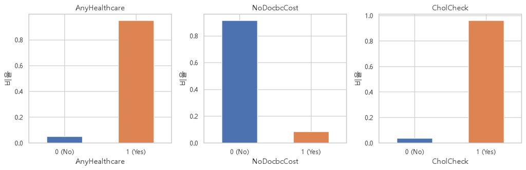

```python
access_vars = ["AnyHealthcare", "NoDocbcCost", "CholCheck"]
for col in access_vars:
    print(f"--- {col} ---")
    print(df_eda[col].value_counts(normalize=True).sort_index())
    print()

fig, axes = plt.subplots(1, 3, figsize=(12, 4))
for ax, col in zip(axes, access_vars):
    df_eda[col].value_counts(normalize=True).sort_index().plot(kind="bar", ax=ax, color=["#4C72B0", "#DD8452"])
    ax.set_title(col)
    ax.set_ylabel("비율")
    ax.set_xticklabels(["0 (No)", "1 (Yes)"], rotation=0)
plt.tight_layout()
plt.show()
```

세 접근성 지표 모두 대부분 "예(접근성 있음)" 쪽에 크게 치우친 분포다 — `AnyHealthcare` 95.1%, `CholCheck` 96.3%가 Yes이고, `NoDocbcCost`는 반대로 91.6%가 "No"(비용장벽 없음)다. 즉 분석 대상은 사실상 **소수의 취약집단**(의료 미보유 4.9%, 비용장벽 경험 8.4%, 미검진 3.7%)이며, 이들이 다수 집단과 결과에서 얼마나 다른지가 핵심 질문이 된다. 표본이 불균형하므로 이후 비율 차이는 절대적 크기보다 방향과 통계적 유의성 중심으로 해석해야 한다.

## 4. 접근성 변수 vs 건강 결과: 교차분석 및 카이제곱검정

각 접근성 변수와 결과지표(`Diabetes_binary`, `PoorGenHlth`, `HighBP`, `HighChol`) 간 비율 차이와 통계적 유의성을 확인한다.

```python
outcome_vars = ["Diabetes_binary", "PoorGenHlth", "HighBP", "HighChol"]

results = []
for a in access_vars:
    for o in outcome_vars:
        ct = pd.crosstab(df_eda[a], df_eda[o])
        chi2, p, dof, exp = chi2_contingency(ct)
        rate0 = df_eda.loc[df_eda[a] == 0, o].mean()
        rate1 = df_eda.loc[df_eda[a] == 1, o].mean()
        results.append({
            "access_var": a, "outcome": o,
            "rate_when_0": round(rate0, 4), "rate_when_1": round(rate1, 4),
            "diff": round(rate1 - rate0, 4), "chi2_p": p
        })

results_df = pd.DataFrame(results)
results_df
```

|  | access_var | outcome | rate_when_0 | rate_when_1 | diff | chi2_p |
| --- | --- | --- | --- | --- | --- | --- |
| 0 | AnyHealthcare | Diabetes_binary | 0.1145 | 0.1406 | 0.0261 | 2.986181e-16 |
| 1 | AnyHealthcare | PoorGenHlth | 0.2284 | 0.1692 | -0.0592 | 4.203328e-65 |
| 2 | AnyHealthcare | HighBP | 0.3452 | 0.4333 | 0.0881 | 2.291157e-83 |
| 3 | AnyHealthcare | HighChol | 0.3321 | 0.4289 | 0.0967 | 2.638219e-100 |
| 4 | NoDocbcCost | Diabetes_binary | 0.1360 | 0.1752 | 0.0392 | 2.218395e-56 |
| 5 | NoDocbcCost | PoorGenHlth | 0.1546 | 0.3625 | 0.2079 | 0.000000e+00 |
| 6 | NoDocbcCost | HighBP | 0.4264 | 0.4573 | 0.0309 | 2.427700e-18 |
| 7 | NoDocbcCost | HighChol | 0.4221 | 0.4458 | 0.0237 | 2.132523e-11 |
| 8 | CholCheck | Diabetes_binary | 0.0254 | 0.1437 | 0.1183 | 3.751399e-233 |
| 9 | CholCheck | PoorGenHlth | 0.1060 | 0.1746 | 0.0686 | 2.226386e-67 |
| 10 | CholCheck | HighBP | 0.1814 | 0.4386 | 0.2572 | 0.000000e+00 |
| 11 | CholCheck | HighChol | 0.2092 | 0.4325 | 0.2233 | 0.000000e+00 |

`results_df`의 각 열이 의미하는 바는 다음과 같다.

- `access_var`, `outcome`: 비교 대상 접근성 변수와 결과지표 이름
- `rate_when_0` / `rate_when_1`: 접근성 변수가 0(미보유/미경험)일 때와 1(보유/경험)일 때 결과지표의 평균 비율
- `diff`: 두 비율의 차이(`rate_when_1` - `rate_when_0`)
- `chi2_p`: 카이제곱 독립성 검정의 p-value — 작을수록(관례상 <0.05) 두 변수가 통계적으로 독립이 아니라는 뜻

접근성 변수와 결과지표가 모두 이진(0/1) 범주형 데이터라, 두 변수의 관계를 볼 때는 상관계수보다 교차표(crosstab)로 그룹별 비율을 직접 비교하는 편이 직관적이다. 그 비율 차이가 표본 크기 대비 우연한 변동인지 통계적으로 유의한 연관인지는 범주형 변수 간 독립성 검정인 카이제곱검정으로 판단한다. 이 단계는 아직 교란변수를 통제하지 않은 원시(raw) 연관성 확인이며, 여기서 유의하게 나온 관계를 5절에서 교란변수 스크리닝 대상으로 이어간다.

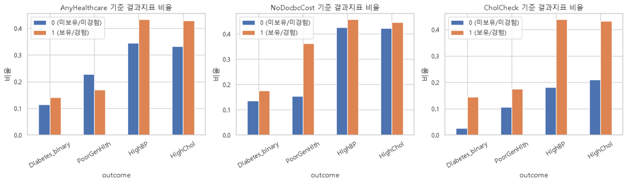

```python
fig, axes = plt.subplots(1, len(access_vars), figsize=(15, 4.5), sharey=False)
for ax, a in zip(axes, access_vars):
    sub = results_df[results_df["access_var"] == a].set_index("outcome")[["rate_when_0", "rate_when_1"]]
    sub.plot(kind="bar", ax=ax)
    ax.set_title(f"{a} 기준 결과지표 비율")
    ax.set_ylabel("비율")
    ax.legend(["0 (미보유/미경험)", "1 (보유/경험)"])
    ax.tick_params(axis="x", rotation=30)
plt.tight_layout()
plt.show()
```

세 접근성 변수 모두 카이제곱검정에서 모든 결과지표와 통계적으로 유의한 연관을 보인다(전부 p<0.001). 방향은 대체로 "접근성 문제가 있을수록 결과가 나쁘다"와 일치하지만 예외가 있다 — `AnyHealthcare`는 `Diabetes_binary`에서 오히려 보험 보유군의 유병률이 더 높고(11.5%→14.1%), `CholCheck`는 당뇨 비율 차이가 극단적으로 크다(2.5%→14.4%, +11.8%p). 이는 개선이 아니라 **검출편향** — 검진·의료 이용을 해야 진단이 기록되는 구조 — 일 가능성이 높다. 반면 `NoDocbcCost`는 `PoorGenHlth`에서 15.5%→36.3%(+20.8%p)로 가장 크고 방향이 일관된 차이를 보여, 뒤의 모델링에서 더 신뢰할 수 있는 신호로 다뤄야 한다.

## 5. 교란변수 선정

교란변수(confounder)는 노출(접근성)과 결과(당뇨) 양쪽에 모두 영향을 미치는 제3의 변수를 말한다. 이런 변수를 통제하지 않으면 접근성과 결과 사이의 관계가 실제보다 과장되거나 왜곡되어 나타날 수 있다(교란편향) — 예를 들어 소득이 낮을수록 의료 접근성도 떨어지고 당뇨 위험도 높다면, 소득을 통제하지 않은 채 접근성만 보면 소득의 효과가 접근성의 효과인 것처럼 섞여 나온다.

로지스틱 회귀에서 어떤 변수를 교란변수(통제변수)로 넣을지는 "조정 후 오즈비가 얼마나 바뀌었는가"로 사후에 정하는 게 아니라, **노출(접근성)과 결과(당뇨) 양쪽에 모두 연관된 변수인가**를 기준으로 사전에 정해야 한다. 아래 3단계로 후보를 스크리닝한다.

1. 도메인 지식으로 후보 나열 (`Income`, `Age`, `Education`, `Sex`, `BMI`, `Smoker`, `PhysActivity`)
2. 접근성 변수·결과변수 양쪽과의 상관관계를 확인해, 두 조건을 동시에 만족하는지 통계적으로 스크리닝
3. 통계만으로는 판단할 수 없는 매개변수(mediator) 가능성을 논리적으로 재검토

### 5.1 후보 나열

```python
candidates = ["Income", "Age", "Education", "Sex", "BMI", "Smoker", "PhysActivity"]
```

### 5.2 상관관계 스크리닝

```python
screen = pd.DataFrame(index=candidates)
for a in access_vars:
    screen[a] = [df_eda[c].corr(df_eda[a]) for c in candidates]
screen["Diabetes_binary"] = [df_eda[c].corr(df_eda["Diabetes_binary"]) for c in candidates]
screen.round(3)
```

|  | AnyHealthcare | NoDocbcCost | CholCheck | Diabetes_binary |
| --- | --- | --- | --- | --- |
| Income | 0.158 | -0.203 | 0.014 | -0.164 |
| Age | 0.138 | -0.120 | 0.090 | 0.177 |
| Education | 0.123 | -0.101 | 0.002 | -0.124 |
| Sex | -0.019 | -0.045 | -0.022 | 0.031 |
| BMI | -0.018 | 0.058 | 0.034 | 0.217 |
| Smoker | -0.023 | 0.049 | -0.010 | 0.061 |
| PhysActivity | 0.036 | -0.062 | 0.004 | -0.118 |

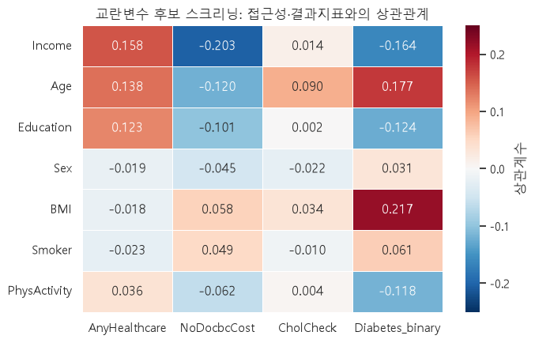

```python
fig, ax = plt.subplots(figsize=(7, 4.5))
sns.heatmap(screen.astype(float), annot=True, fmt=".3f", cmap="RdBu_r", center=0,
            vmin=-0.25, vmax=0.25, linewidths=0.6, linecolor="white",
            cbar_kws={"label": "상관계수"}, ax=ax)
ax.set_title("교란변수 후보 스크리닝: 접근성·결과지표와의 상관관계")
ax.set_xlabel("")
ax.set_ylabel("")
plt.tight_layout()
plt.show()
```

이 히트맵은 후보 교란변수(`Income`, `Age`, `Education`, `Sex`, `BMI`, `Smoker`, `PhysActivity`)가 접근성 변수 3개, 그리고 `Diabetes_binary`와 각각 얼마나 상관돼 있는지를 색으로 보여준다. 색이 파란색·빨간색으로 진하고 0에서 멀수록 상관관계가 강하다는 뜻이다. 다만 히트맵만으로는 "접근성과의 연관"과 "결과와의 연관"을 동시에 비교하기 어려우므로, 아래 산점도에서 이 값들을 두 축으로 나눠 다시 살펴본다.

```
              access_strength  outcome_strength  combined_score
Age                    0.1160            0.1774          0.0206
Income                 0.1251            0.1639          0.0205
Education              0.0749            0.1245          0.0093
BMI                    0.0371            0.2168          0.0080
PhysActivity           0.0338            0.1181          0.0040
Smoker                 0.0274            0.0608          0.0017
Sex                    0.0288            0.0314          0.0009
```

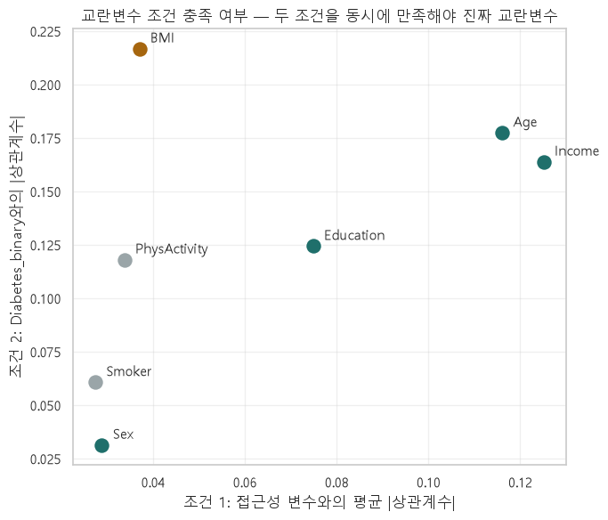

```python
# 조건 1: 접근성 변수들과의 평균 |상관관계| / 조건 2: 결과(Diabetes_binary)와의 |상관관계|
screen["access_strength"] = screen[access_vars].abs().mean(axis=1)
screen["outcome_strength"] = screen["Diabetes_binary"].abs()

# 두 조건을 곱한 종합 점수 (아래 해석에서 언급하는 수치의 근거)
screen["combined_score"] = screen["access_strength"] * screen["outcome_strength"]
print(screen[["access_strength", "outcome_strength", "combined_score"]].sort_values("combined_score", ascending=False).round(4))

fig, ax = plt.subplots(figsize=(7, 6))
colors = {"Income": "#1F6F6B", "Age": "#1F6F6B", "Education": "#1F6F6B", "Sex": "#1F6F6B",
          "BMI": "#A6660F", "Smoker": "#9AA5A8", "PhysActivity": "#9AA5A8"}
for c in candidates:
    x, y = screen.loc[c, "access_strength"], screen.loc[c, "outcome_strength"]
    ax.scatter(x, y, s=170, color=colors[c], edgecolor="white", linewidth=1.2, zorder=3)
    ax.annotate(c, (x, y), textcoords="offset points", xytext=(9, 5), fontsize=10.5)
ax.set_xlabel("조건 1: 접근성 변수와의 평균 |상관계수|")
ax.set_ylabel("조건 2: Diabetes_binary와의 |상관계수|")
ax.set_title("교란변수 조건 충족 여부 — 두 조건을 동시에 만족해야 진짜 교란변수")
ax.grid(alpha=0.3)
plt.tight_layout()
plt.show()
```

산점도에서 `Income`(0.125·0.164)과 `Age`(0.116·0.177)는 x축(접근성 연관)과 y축(결과 연관) 모두 상위권에 위치해 교란변수의 두 조건을 동시에 만족한다 — 가장 확실한 교란변수 후보다. `Education`(0.075·0.124)도 두 축 모두 준수해 교란변수로 채택할 만하다. 반면 `BMI`는 y축에서 전체 후보 중 가장 높은 값(0.217)을 보이지만 x축은 가장 낮은 축에 속해(0.037) 그래프 왼쪽 위 구석에 혼자 떨어져 있다 — 결과와는 강하게 연관되지만 접근성과는 거의 무관하다는 뜻으로, 교란변수 조건 중 절반만 만족한다. `Smoker`, `Sex`, `PhysActivity`는 두 축 모두 낮아 왼쪽 아래에 뭉쳐 있어 교란변수로 채택할 통계적 근거가 약하다.

두 조건을 곱한 종합 점수로 순위를 매기면 `Age`(0.0206) ≈ `Income`(0.0205) > `Education`(0.0093) > `BMI`(0.0080) 순인데, 이 점수는 두 축을 하나로 뭉개기 때문에 `BMI`처럼 한쪽만 극단적인 경우를 과소평가할 수 있다 — 그래서 점수 하나보다는 산점도로 두 조건을 따로 보는 게 더 정확하다.

### 5.3 매개변수 여부 재검토

산점도까지는 상관관계로 확인할 수 있지만, "이 변수가 접근성의 원인 쪽인지, 접근성 때문에 생기는 결과(매개변수)인지"는 통계만으로 구분할 수 없고 논리적 판단이 필요하다.

- `Income`, `Age`, `Education`, `Sex`: 접근성이 이 값들을 바꿀 수는 없다 — 오히려 소득이 낮아서 접근성이 떨어지는 것이므로 방향이 명확한 안전한 교란변수다.
- `BMI`: "접근성이 없어서 예방관리를 못 받아 BMI가 올라갔다"는 반대 방향 인과도 성립할 수 있어, 매개변수일 가능성을 배제할 수 없다 — 통제변수로는 넣되 해석에 유의해야 한다.

**최종 선정**: `Income`, `Age`, `Education`, `Sex`를 핵심 교란변수로, `BMI`는 매개변수 가능성이 있는 강한 독립 위험요인으로 구분해 이후 모델에 함께 포함한다.

## 6. 교란변수(소득) 심층 층화분석

앞선 스크리닝에서 `Income`이 가장 확실한 교란변수 후보로 확인됐다. 소득 구간별로 접근성 변수와 결과지표가 어떻게 같이 움직이는지 좀 더 자세히 들여다본다.

```python
income_order = [income_labels[i] for i in range(1, 9)]

income_summary = df_eda.groupby("IncomeGroup").agg(
    n=("Income", "size"),
    NoDocbcCost_rate=("NoDocbcCost", "mean"),
    AnyHealthcare_rate=("AnyHealthcare", "mean"),
    Diabetes_rate=("Diabetes_binary", "mean"),
    PoorGenHlth_rate=("PoorGenHlth", "mean"),
).reindex(income_order)

# 구간별 인원이 크게 다르므로(최하위 3.9% vs 최상위 35.6%) 표본 비중을 함께 본다
income_summary["표본_비중"] = income_summary["n"] / len(df_eda)
income_summary["누적_비중"] = income_summary["표본_비중"].cumsum()
income_summary.round(4)
```

| IncomeGroup | n | NoDocbcCost_rate | AnyHealthcare_rate | Diabetes_rate | PoorGenHlth_rate | 표본_비중 | 누적_비중 |
| --- | --- | --- | --- | --- | --- | --- | --- |
| <10k | 9811 | 0.2137 | 0.8655 | 0.2429 | 0.4875 | 0.0387 | 0.0387 |
| 10-15k | 11783 | 0.1871 | 0.9100 | 0.2619 | 0.4556 | 0.0464 | 0.0851 |
| 15-20k | 15994 | 0.1743 | 0.8958 | 0.2231 | 0.3628 | 0.0630 | 0.1482 |
| 20-25k | 20135 | 0.1481 | 0.9056 | 0.2013 | 0.2881 | 0.0794 | 0.2275 |
| 25-35k | 25883 | 0.1129 | 0.9311 | 0.1740 | 0.2194 | 0.1020 | 0.3296 |
| 35-50k | 36470 | 0.0828 | 0.9479 | 0.1451 | 0.1553 | 0.1438 | 0.4733 |
| 50-75k | 43219 | 0.0606 | 0.9680 | 0.1218 | 0.1124 | 0.1704 | 0.6437 |
| 75k+ | 90385 | 0.0301 | 0.9845 | 0.0796 | 0.0630 | 0.3563 | 1.0000 |

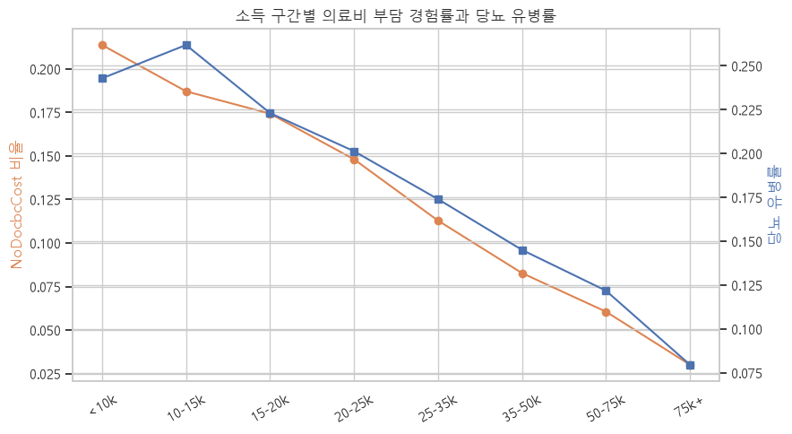

```
Spearman corr Income vs NoDocbcCost: -0.19673398322516558
Spearman corr Income vs Diabetes_binary: -0.16330469335765088
```

```python
fig, ax1 = plt.subplots(figsize=(9, 5))
x = np.arange(len(income_order))
ax1.plot(x, income_summary["NoDocbcCost_rate"], marker="o", label="NoDocbcCost 비율", color="#DD8452")
ax1.set_ylabel("NoDocbcCost 비율", color="#DD8452")
ax1.set_xticks(x)
ax1.set_xticklabels(income_order, rotation=30)

ax2 = ax1.twinx()
ax2.plot(x, income_summary["Diabetes_rate"], marker="s", label="당뇨 유병률", color="#4C72B0")
ax2.set_ylabel("당뇨 유병률", color="#4C72B0")

plt.title("소득 구간별 의료비 부담 경험률과 당뇨 유병률")
fig.tight_layout()
plt.show()

# 소득 구간별 상관: NoDocbcCost가 낮은 소득일수록 늘어나는지 스피어만 상관으로 확인
print("Spearman corr Income vs NoDocbcCost:", df_eda["Income"].corr(df_eda["NoDocbcCost"], method="spearman"))
print("Spearman corr Income vs Diabetes_binary:", df_eda["Income"].corr(df_eda["Diabetes_binary"], method="spearman"))
```

소득 구간이 낮아질수록 비용장벽 경험률과 당뇨 유병률이 함께, 그리고 거의 단조적으로 증가한다(스피어만 상관 각각 -0.197, -0.163). 최하위 소득군(<10k)은 최상위군(75k+) 대비 비용장벽 7배(21.4% vs 3.0%), 주관적 건강불량 7.7배(48.8% vs 6.3%), 당뇨 유병률 3배(24.3% vs 8.0%) 높다. `Income`이 접근성과 결과 모두를 강하게 설명하는 대표적 교란변수임이 확인되므로, 이후 모델링에서 반드시 통제해야 한다.

## 7. 기초 모델링 - 로지스틱 회귀 (오즈비 비교)

접근성 변수만 넣은 **비보정(unadjusted) 모델**과 `Income`, `Education`, `Age`, `Sex`, `BMI`를 통제한 **보정(adjusted) 모델**을 비교해, 접근성 변수의 오즈비가 교란변수 통제 후에도 유의하게 남는지 확인한다.

**모델 선택 근거**: 로지스틱 회귀를 쓰는 이유는 (1) 타깃이 이진 변수(`Diabetes_binary`)이고, (2) 계수를 오즈비(odds ratio)로 바꿔 "접근성이 결과에 미치는 영향의 방향과 크기"를 직관적으로 설명할 수 있기 때문이다. 이 절의 목적은 예측이 아니라 **설명(explanatory**)이므로, 예측 성능이 더 좋을 수 있는 트리 기반 모델 대신 해석 가능한 로지스틱 회귀를 택했다 — 예측 성능 자체는 8절에서 별도로 다루고, 트리 기반 모델을 실제로 학습시켜 성능 차이를 확인하는 비교는 8.2절에 있다.

타깃: `Diabetes_binary`

```python
def fit_logit_or(formula, data, label):
    model = smf.logit(formula, data=data).fit(disp=0)
    params = model.params
    conf = model.conf_int()
    conf.columns = ["ci_low", "ci_high"]
    or_table = np.exp(pd.concat([params, conf], axis=1))
    or_table.columns = ["odds_ratio", "ci_low", "ci_high"]
    or_table["p_value"] = model.pvalues
    or_table["model"] = label
    return model, or_table

unadj_model, unadj_or = fit_logit_or(
    "Diabetes_binary ~ AnyHealthcare + NoDocbcCost + CholCheck",
    df_eda, "unadjusted"
)
adj_model, adj_or = fit_logit_or(
    "Diabetes_binary ~ AnyHealthcare + NoDocbcCost + CholCheck + Income + Education + Age + Sex + BMI",
    df_eda, "adjusted"
)

compare = pd.concat([
    unadj_or.loc[access_vars],
    adj_or.loc[access_vars]
]).round(4)
compare
```

|  | odds_ratio | ci_low | ci_high | p_value | model |
| --- | --- | --- | --- | --- | --- |
| AnyHealthcare | 1.2882 | 1.2150 | 1.3657 | 0.0 | unadjusted |
| NoDocbcCost | 1.4663 | 1.4110 | 1.5237 | 0.0 | unadjusted |
| CholCheck | 6.4611 | 5.6812 | 7.3481 | 0.0 | unadjusted |
| AnyHealthcare | 1.2271 | 1.1522 | 1.3068 | 0.0 | adjusted |
| NoDocbcCost | 1.3666 | 1.3098 | 1.4258 | 0.0 | adjusted |
| CholCheck | 5.0983 | 4.4655 | 5.8208 | 0.0 | adjusted |

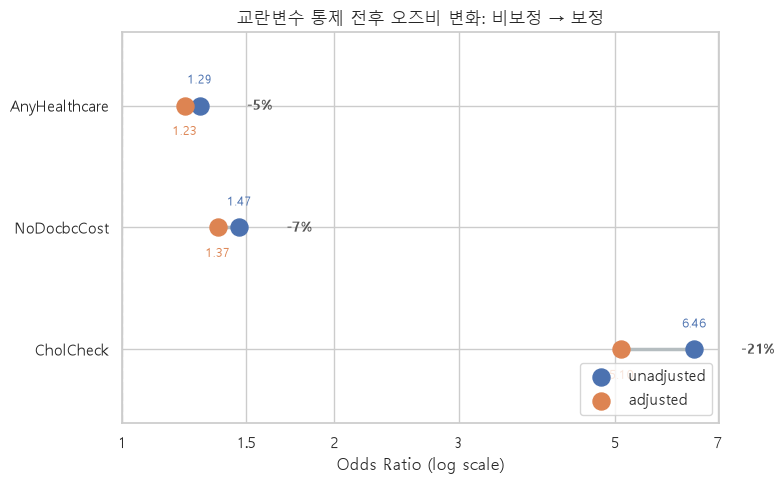

```python
# 비포/애프터 슬로프(덤벨) 그래프: 비보정 -> 보정으로 오즈비가 얼마나, 어느 방향으로 움직였는지 강조
fig, ax = plt.subplots(figsize=(8, 5))
plot_order = ["CholCheck", "NoDocbcCost", "AnyHealthcare"]

for y, v in enumerate(plot_order):
    unadj_val = unadj_or.loc[v, "odds_ratio"]
    adj_val = adj_or.loc[v, "odds_ratio"]
    pct_change = (adj_val - unadj_val) / unadj_val * 100

    ax.plot([unadj_val, adj_val], [y, y], color="#B5BDC0", linewidth=2.5, zorder=1)
    ax.scatter(unadj_val, y, s=150, color="#4C72B0", zorder=3,
               label="unadjusted" if y == 0 else None)
    ax.scatter(adj_val, y, s=150, color="#DD8452", zorder=3,
               label="adjusted" if y == 0 else None)

    ax.annotate(f"{unadj_val:.2f}", (unadj_val, y), textcoords="offset points",
                xytext=(0, 14), ha="center", va="bottom", fontsize=9, color="#4C72B0")
    ax.annotate(f"{adj_val:.2f}", (adj_val, y), textcoords="offset points",
                xytext=(0, -14), ha="center", va="top", fontsize=9, color="#DD8452")
    ax.annotate(f"{pct_change:+.0f}%", (max(unadj_val, adj_val), y), textcoords="offset points",
                xytext=(34, 0), ha="left", va="center", fontsize=10, fontweight="bold", color="#555555")

ax.set_xscale("log")
ax.minorticks_off()
xticks = [1, 1.5, 2, 3, 5, 7]
ax.set_xticks(xticks)
ax.set_xticklabels([str(t) for t in xticks])
ax.axvline(1, color="gray", linestyle="--", zorder=0)
ax.set_yticks(range(len(plot_order)))
ax.set_yticklabels(plot_order)
ax.set_ylim(-0.6, len(plot_order) - 0.4)
ax.set_xlabel("Odds Ratio (log scale)")
ax.set_title("교란변수 통제 전후 오즈비 변화: 비보정 → 보정")
ax.legend(loc="lower right")
plt.tight_layout()
plt.show()
```

소득·연령·성별·교육·BMI를 통제해도 세 접근성 변수의 오즈비는 모두 유의하게 남지만 크기는 줄어든다(`AnyHealthcare` 1.29→1.23, `NoDocbcCost` 1.47→1.37, `CholCheck` 6.46→5.10). `CholCheck`의 오즈비가 보정 후에도 5배를 넘는 것은 실제 위험 증가라기보다 "검진을 받아야 당뇨를 진단받는다"는 구조적 이유가 크다고 봐야 한다. 반면 `NoDocbcCost`는 보정 후에도 1.37로 독립적 효과가 뚜렷해, 비용장벽이 소득과 별개로 당뇨 진단·관리에 영향을 준다는 근거가 된다.

### 7.1 모델 가정 점검: 다중공선성(VIF) & 선형성(Box-Tidwell)

앞 절의 오즈비를 신뢰하려면 로지스틱 회귀가 전제하는 두 가지 조건을 확인해야 한다.

**(1) 다중공선성**: 예측변수끼리 강하게 겹치면 "이 효과가 어느 변수 몫인지"를 모델이 가려내지 못한다. 계수가 편향되는 것은 아니지만 추정이 불안정해져 표준오차가 커지고 신뢰구간이 넓어지며, 표본이 조금만 달라져도 값이 크게 흔들린다. 이 절의 목적이 접근성 변수 **각각의 독립적 효과**를 읽는 것이므로 반드시 짚어야 한다.

**(2) 로짓 선형성**: 로지스틱 회귀는 연속형 예측변수가 로그오즈(logit)와 직선 관계라고 가정한다. `BMI`로 치면 20에서 25로 오를 때와 35에서 40으로 오를 때 당뇨 로그오즈가 같은 폭으로 증가해야 한다는 뜻인데, 실제 관계는 곡선일 수 있다. 이 가정이 깨지면 해당 변수의 계수가 구간별 실제 관계를 제대로 대표하지 못한다.

이 가정은 모델에 연속형(선형) 항으로 넣은 예측변수 전체에 적용된다. 이 데이터셋에서 실수값을 갖는 연속형 변수는 `BMI`뿐이므로 Box-Tidwell 검정은 `BMI`에 대해서만 진행한다. 다만 `Income`, `Education`, `Age`도 순서형 정수 코드를 범주형으로 더미화하지 않고 선형항 그대로 넣었으므로 같은 가정이 걸려 있다 — 이 세 변수는 Box-Tidwell 대신 범주형(더미) 모델과 비교하는 방식으로 7.1절 끝에서 별도로 확인한다(이진 변수는 애초에 직선/곡선을 구분할 수 없는 두 점이라 대상이 아니다).

```python
from statsmodels.stats.outliers_influence import variance_inflation_factor

X_vif = sm.add_constant(df_eda[["AnyHealthcare", "NoDocbcCost", "CholCheck", "Income", "Education", "Age", "Sex", "BMI"]])
vif_df = pd.DataFrame({
    "variable": X_vif.columns,
    "VIF": [variance_inflation_factor(X_vif.values, i) for i in range(X_vif.shape[1])]
})
vif_df = vif_df[vif_df["variable"] != "const"].reset_index(drop=True)
vif_df
```

|  | variable | VIF |
| --- | --- | --- |
| 0 | AnyHealthcare | 1.108642 |
| 1 | NoDocbcCost | 1.109160 |
| 2 | CholCheck | 1.022786 |
| 3 | Income | 1.352114 |
| 4 | Education | 1.269509 |
| 5 | Age | 1.071747 |
| 6 | Sex | 1.024262 |
| 7 | BMI | 1.023587 |

VIF(Variance Inflation Factor, 분산팽창인자)는 "이 변수를 나머지 예측변수들로 회귀시켰을 때 얼마나 잘 설명되는가"를 수치로 옮긴 값이다. 1이면 다른 변수와 전혀 겹치지 않는다는 뜻이고, 겹칠수록 값이 커진다. 통상 5를 넘으면 주의, 10을 넘으면 문제로 본다.

결과는 `CholCheck` 1.02에서 `Income` 1.35까지로 전부 기준을 크게 밑돈다. 상대적으로 높은 축인 `Income`과 `Education`(1.27)이 서로 상관된 결과지만 그 정도가 미미하다. 예측변수 간 정보 중복이 사실상 없으므로 각 접근성 변수의 오즈비를 독립적인 효과로 읽어도 무방하다.

```python
# Box-Tidwell: BMI * ln(BMI) 상호작용항이 유의하면 선형성 가정 위반
df_bt = df_eda.copy()
df_bt["BMI_log_BMI"] = df_bt["BMI"] * np.log(df_bt["BMI"])

bt_model = smf.logit(
    "Diabetes_binary ~ AnyHealthcare + NoDocbcCost + CholCheck + Income + Education + Age + Sex + BMI + BMI_log_BMI",
    data=df_bt
).fit(disp=0)
bt_model.summary2().tables[1].loc[["BMI", "BMI_log_BMI"]]
```

|  | Coef. | Std.Err. | z | P>\|z\| | [0.025 | 0.975] |
| --- | --- | --- | --- | --- | --- | --- |
| BMI | 1.031006 | 0.019180 | 53.75558 | 0.0 | 0.993415 | 1.068597 |
| BMI_log_BMI | -0.205822 | 0.004181 | -49.22305 | 0.0 | -0.214018 | -0.197627 |

Box-Tidwell 검정은 모델에 `BMI × ln(BMI)` 항을 하나 더 넣어보는 방법이다. `BMI`와 로짓의 관계가 정말 직선이라면 이 항은 새로 설명할 것이 없어 유의하지 않아야 한다. 반대로 유의하게 나오면 직선으로는 담기지 않는 곡률이 남아 있다는 뜻이다.

결과는 `BMI_log_BMI` 항이 강하게 유의하다(계수 -0.206, p<0.001) — `BMI`와 로짓 사이에 완전한 선형 관계가 성립하지 않는다. 계수가 음수라는 것은 `BMI`가 커질수록 로그오즈 증가폭이 점점 완만해진다는 의미다.

다만 `BMI`는 접근성 변수의 오즈비를 해석하기 위해 넣은 통제변수일 뿐이므로, 가정 위반 자체보다 중요한 것은 **이 비선형성이 접근성 변수에 대한 결론을 흔드는가**다. 아래에서 `BMI`를 구간화(binning)해 비선형성을 흡수한 모델과 직접 비교해 확인한다.

```python
# BMI를 CDC 표준 구간(저체중/정상/과체중/비만)으로 나눠 비선형성을 흡수한 모델과 비교
df_bmi_bin = df_eda.copy()
df_bmi_bin["BMI_cat"] = pd.cut(
    df_bmi_bin["BMI"], bins=[0, 18.5, 25, 30, 100],
    labels=["저체중", "정상", "과체중", "비만"]
)

bmi_bin_model = smf.logit(
    "Diabetes_binary ~ AnyHealthcare + NoDocbcCost + CholCheck + Income + Education + Age + Sex + C(BMI_cat)",
    data=df_bmi_bin
).fit(disp=0)

bmi_bin_ci = np.exp(bmi_bin_model.conf_int())
bmi_bin_ci.columns = ["ci_low", "ci_high"]
bmi_bin_or = pd.DataFrame({
    "odds_ratio": np.exp(bmi_bin_model.params),
    "ci_low": bmi_bin_ci["ci_low"],
    "ci_high": bmi_bin_ci["ci_high"],
    "p_value": bmi_bin_model.pvalues
}).loc[access_vars]

compare_bmi = pd.concat([
    adj_or.loc[access_vars, ["odds_ratio", "ci_low", "ci_high", "p_value"]].assign(BMI_처리="연속형(기존 모델)"),
    bmi_bin_or.assign(BMI_처리="구간화(4단계)")
])
compare_bmi.round(4)
```

|  | odds_ratio | ci_low | ci_high | p_value | BMI_처리 |
| --- | --- | --- | --- | --- | --- |
| AnyHealthcare | 1.2271 | 1.1522 | 1.3068 | 0.0 | 연속형(기존 모델) |
| NoDocbcCost | 1.3666 | 1.3098 | 1.4258 | 0.0 | 연속형(기존 모델) |
| CholCheck | 5.0983 | 4.4655 | 5.8208 | 0.0 | 연속형(기존 모델) |
| AnyHealthcare | 1.2253 | 1.1512 | 1.3042 | 0.0 | 구간화(4단계) |
| NoDocbcCost | 1.3583 | 1.3022 | 1.4169 | 0.0 | 구간화(4단계) |
| CholCheck | 4.9119 | 4.3093 | 5.5987 | 0.0 | 구간화(4단계) |

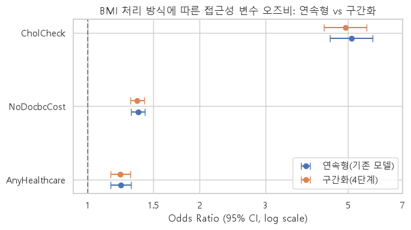

```python
fig, ax = plt.subplots(figsize=(7, 4))
scenario_colors = {"연속형(기존 모델)": "#4C72B0", "구간화(4단계)": "#DD8452"}
for i, scenario in enumerate(["연속형(기존 모델)", "구간화(4단계)"]):
    sub = compare_bmi[compare_bmi["BMI_처리"] == scenario].loc[access_vars]
    y = np.arange(len(access_vars)) + (i * 0.15)
    ax.errorbar(sub["odds_ratio"], y,
                xerr=[sub["odds_ratio"] - sub["ci_low"], sub["ci_high"] - sub["odds_ratio"]],
                fmt="o", label=scenario, capsize=4, color=scenario_colors[scenario])
ax.axvline(1, color="gray", linestyle="--")
ax.set_xscale("log")
ax.minorticks_off()
xticks = [1, 1.5, 2, 3, 5, 7]
ax.set_xticks(xticks)
ax.set_xticklabels([str(t) for t in xticks])
ax.set_yticks(np.arange(len(access_vars)) + 0.075)
ax.set_yticklabels(access_vars)
ax.set_xlabel("Odds Ratio (95% CI, log scale)")
ax.set_title("BMI 처리 방식에 따른 접근성 변수 오즈비: 연속형 vs 구간화")
ax.legend()
plt.tight_layout()
plt.show()
```

`BMI`를 연속형으로 쓰든 4단계로 구간화하든 접근성 변수의 오즈비는 거의 변하지 않는다(`AnyHealthcare` 1.227→1.225, `NoDocbcCost` 1.367→1.358, `CholCheck` 5.098→4.912, 유의성도 모두 p<0.001로 동일). 그래프에서 보듯 두 모델의 95% 신뢰구간은 세 변수 모두에서 거의 완전히 겹친다(`NoDocbcCost` 1.310~1.426 vs 1.302~1.417, `CholCheck` 4.47~5.82 vs 4.31~5.60) — 두 모델의 차이가 통계적으로 구분되지 않는 수준이라는 뜻이다.

Box-Tidwell 검정이 지적한 `BMI`-로짓 간 비선형성은 실제로 존재하지만, 그 비선형성을 구간화로 흡수해도 접근성 변수에 대한 결론(오즈비 크기와 방향)은 바뀌지 않는다 — `BMI`를 통제변수로만 쓰는 이번 분석의 목적에서는 이 비선형성이 결과 해석을 흔드는 문제가 아님을 직접 확인했다.

### 7.1b `Income` / `Education` / `Age` 선형성 확인

`BMI`와 마찬가지로 `Income`, `Education`, `Age`도 순서형 코드를 범주형으로 나누지 않고 정수 그대로 선형항에 넣었으므로, 로짓과의 선형 관계 가정이 똑같이 적용된다. 세 변수는 6~13개의 이산 구간뿐이라 Box-Tidwell(연속형 변수 대상)보다는, 세 변수를 모두 범주형(`C()`, 구간마다 더미변수)으로 바꾼 모델과 직접 비교해 접근성 변수의 오즈비가 흔들리는지로 실질적 영향을 확인한다.

```python
# Income/Education/Age를 선형항 대신 범주형(더미)으로 바꿔, 순서형 코드를 그대로 넣은 것이
# 접근성 변수의 오즈비 결론에 영향을 주는지 확인
from scipy.stats import chi2

cat_model = smf.logit(
    "Diabetes_binary ~ AnyHealthcare + NoDocbcCost + CholCheck + C(Income) + C(Education) + C(Age) + Sex + BMI",
    data=df_eda
).fit(disp=0)

cat_ci = np.exp(cat_model.conf_int())
cat_ci.columns = ["ci_low", "ci_high"]
cat_or = pd.DataFrame({
    "odds_ratio": np.exp(cat_model.params),
    "ci_low": cat_ci["ci_low"],
    "ci_high": cat_ci["ci_high"],
    "p_value": cat_model.pvalues
}).loc[access_vars]

compare_linearity = pd.concat([
    adj_or.loc[access_vars, ["odds_ratio", "ci_low", "ci_high", "p_value"]].assign(처리="선형(기존 모델)"),
    cat_or.assign(처리="범주형(Income/Education/Age 더미화)")
])

# 우도비검정: 범주형 모델이 선형 모델보다 유의하게 더 잘 맞는지
lr_stat = 2 * (cat_model.llf - adj_model.llf)
lr_dof = cat_model.df_model - adj_model.df_model
lr_p = chi2.sf(lr_stat, lr_dof)
print(f"LR test (범주형 vs 선형): stat={lr_stat:.1f}, dof={lr_dof:.0f}, p={lr_p:.4g}")
compare_linearity.round(4)
```

```
LR test (범주형 vs 선형): stat=1634.6, dof=21, p=0
```

|  | odds_ratio | ci_low | ci_high | p_value | 처리 |
| --- | --- | --- | --- | --- | --- |
| AnyHealthcare | 1.2271 | 1.1522 | 1.3068 | 0.0 | 선형(기존 모델) |
| NoDocbcCost | 1.3666 | 1.3098 | 1.4258 | 0.0 | 선형(기존 모델) |
| CholCheck | 5.0983 | 4.4655 | 5.8208 | 0.0 | 선형(기존 모델) |
| AnyHealthcare | 1.2165 | 1.1418 | 1.2961 | 0.0 | 범주형(Income/Education/Age 더미화) |
| NoDocbcCost | 1.3215 | 1.2662 | 1.3793 | 0.0 | 범주형(Income/Education/Age 더미화) |
| CholCheck | 5.1259 | 4.4897 | 5.8522 | 0.0 | 범주형(Income/Education/Age 더미화) |

우도비검정(likelihood ratio test)으로 보면 범주형 모델이 선형 모델보다 통계적으로 유의하게 더 잘 맞는다(LR=1634.6, df=21, p<0.001) — `Income`/`Education`/`Age`를 정수 그대로 넣는 선형 가정이 엄밀하게는 성립하지 않는다는 뜻이다. 다만 접근성 변수의 오즈비는 거의 흔들리지 않는다(`AnyHealthcare` 1.227→1.217, `NoDocbcCost` 1.367→1.322, `CholCheck` 5.098→5.126이고, 세 변수 모두 95% 신뢰구간이 두 모델에서 크게 겹친다). `BMI`에서 확인한 것과 같은 패턴이다 — 세 변수 자체의 비선형성은 실재하지만, 통제변수로만 쓰는 이번 분석의 목적(접근성 변수의 독립적 효과 추정)에서는 이 비선형성이 결론을 바꾸지 않는다. `NoDocbcCost`가 상대적으로 더 크게 움직인 것(약 -3.3%p)은 소득·연령 구간 사이의 비선형 관계가 세 접근성 변수 중 이 변수와 가장 겹쳐 있다는 뜻으로 읽을 수 있지만, 여전히 유의하고(p<0.001) 방향도 그대로다.

### 7.2 민감도 분석: `CholCheck` 제외 시 오즈비 변화

`CholCheck`의 큰 오즈비(5.10)를 검출편향 — 검진을 받아야 진단이 기록되는 구조 — 으로 의심하고 있다면, 이 변수를 모델에서 아예 빼봤을 때 나머지 접근성 변수들의 오즈비가 얼마나 흔들리는지 확인해 그 의심을 검증해본다.

```python
adj_model_nocc, adj_or_nocc = fit_logit_or(
    "Diabetes_binary ~ AnyHealthcare + NoDocbcCost + Income + Education + Age + Sex + BMI",
    df_eda, "CholCheck 제외"
)

sensitivity = pd.concat([
    adj_or.loc[["AnyHealthcare", "NoDocbcCost"]].assign(model="CholCheck 포함(기존)"),
    adj_or_nocc.loc[["AnyHealthcare", "NoDocbcCost"]]
])[["odds_ratio", "ci_low", "ci_high", "p_value", "model"]].round(4)
sensitivity
```

|  | odds_ratio | ci_low | ci_high | p_value | model |
| --- | --- | --- | --- | --- | --- |
| AnyHealthcare | 1.2271 | 1.1522 | 1.3068 | 0.0 | CholCheck 포함(기존) |
| NoDocbcCost | 1.3666 | 1.3098 | 1.4258 | 0.0 | CholCheck 포함(기존) |
| AnyHealthcare | 1.3321 | 1.2514 | 1.4179 | 0.0 | CholCheck 제외 |
| NoDocbcCost | 1.3432 | 1.2876 | 1.4012 | 0.0 | CholCheck 제외 |

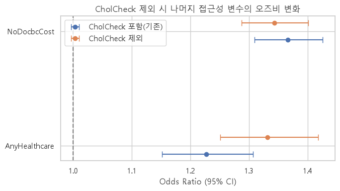

```python
fig, ax = plt.subplots(figsize=(7, 4))
compare_vars = ["AnyHealthcare", "NoDocbcCost"]
scenario_colors = {"CholCheck 포함(기존)": "#4C72B0", "CholCheck 제외": "#DD8452"}
for i, scenario in enumerate(["CholCheck 포함(기존)", "CholCheck 제외"]):
    sub = sensitivity[sensitivity["model"] == scenario].loc[compare_vars]
    y = np.arange(len(compare_vars)) + (i * 0.15)
    ax.errorbar(sub["odds_ratio"], y,
                xerr=[sub["odds_ratio"] - sub["ci_low"], sub["ci_high"] - sub["odds_ratio"]],
                fmt="o", label=scenario, capsize=4, color=scenario_colors[scenario])
ax.axvline(1, color="gray", linestyle="--")
ax.set_yticks(np.arange(len(compare_vars)) + 0.075)
ax.set_yticklabels(compare_vars)
ax.set_xlabel("Odds Ratio (95% CI)")
ax.set_title("CholCheck 제외 시 나머지 접근성 변수의 오즈비 변화")
ax.legend()
plt.tight_layout()
plt.show()
```

```python
# 왜 변수마다 다르게 반응하는지: CholCheck와의 상관관계로 확인
print("corr(AnyHealthcare, CholCheck):", round(df_eda["AnyHealthcare"].corr(df_eda["CholCheck"]), 4))
print("corr(NoDocbcCost, CholCheck):", round(df_eda["NoDocbcCost"].corr(df_eda["CholCheck"]), 4))
print()
print("AnyHealthcare 비율 (CholCheck 그룹별):")
print(df_eda.groupby("CholCheck")["AnyHealthcare"].mean().round(4))
```

```
corr(AnyHealthcare, CholCheck): 0.1176
corr(NoDocbcCost, CholCheck): -0.0583

AnyHealthcare 비율 (CholCheck 그룹별):
CholCheck
0.0    0.8222
1.0    0.9561
Name: AnyHealthcare, dtype: float64
```

`CholCheck`를 빼자 `NoDocbcCost`의 오즈비는 1.37→1.34로 거의 그대로였지만, `AnyHealthcare`는 오히려 1.23→1.33으로 **더 커졌다**. 이유는 상관관계에 있다 — `AnyHealthcare`와 `CholCheck`의 상관은 0.118로 서로 꽤 연결돼 있는 반면(보험 있는 그룹의 콜레스테롤 검진율 95.6% vs 없는 그룹 82.2%), `NoDocbcCost`와 `CholCheck`의 상관은 -0.058로 거의 무관하다.

즉 `CholCheck`를 모델에서 빼도 검출편향이라는 근본 문제는 사라지지 않고, 서로 얽혀 있던 `AnyHealthcare` 쪽으로 옮겨갈 뿐이다. `Diabetes_binary` 자체가 "진단받은 적 있는지"를 묻는 변수라는 구조적 한계 때문에 생기는 편향이라, 특정 변수 하나를 제거한다고 해결되지 않는다. 반대로 `NoDocbcCost`는 이 민감도 분석에서도 거의 흔들리지 않아, 세 접근성 지표 중 가장 견고한 신호라는 앞선 결론을 다시 한번 뒷받침한다.

### 7.3 보조 결과지표: 주관적 건강상태 불량(`PoorGenHlth`)

당뇨 진단 여부 외에, 좀 더 포괄적인 결과지표인 주관적 건강상태(Fair/Poor=1)에 대해서도 동일한 방식으로 비교한다.

```python
unadj_model_g, unadj_or_g = fit_logit_or(
    "PoorGenHlth ~ AnyHealthcare + NoDocbcCost + CholCheck",
    df_eda, "unadjusted"
)
adj_model_g, adj_or_g = fit_logit_or(
    "PoorGenHlth ~ AnyHealthcare + NoDocbcCost + CholCheck + Income + Education + Age + Sex + BMI",
    df_eda, "adjusted"
)

compare_g = pd.concat([
    unadj_or_g.loc[access_vars],
    adj_or_g.loc[access_vars]
]).round(4)
compare_g
```

|  | odds_ratio | ci_low | ci_high | p_value | model |
| --- | --- | --- | --- | --- | --- |
| AnyHealthcare | 0.9594 | 0.9158 | 1.0051 | 0.0806 | unadjusted |
| NoDocbcCost | 3.1760 | 3.0781 | 3.2771 | 0.0000 | unadjusted |
| CholCheck | 2.0832 | 1.9467 | 2.2294 | 0.0000 | unadjusted |
| AnyHealthcare | 1.3210 | 1.2559 | 1.3895 | 0.0000 | adjusted |
| NoDocbcCost | 2.4574 | 2.3727 | 2.5453 | 0.0000 | adjusted |
| CholCheck | 1.7751 | 1.6521 | 1.9073 | 0.0000 | adjusted |

당뇨보다 포괄적인 지표인 주관적 건강상태에서는 접근성 변수의 효과가 당뇨 모델보다 훨씬 크게 나타난다. 특히 `NoDocbcCost`는 비보정 오즈비 3.18, 보정 후에도 2.46으로 매우 강하게 유의해, 비용장벽이 특정 질환 하나보다 **전반적 건강 수준**에 미치는 영향이 크다는 것을 다시 확인시켜 준다. `AnyHealthcare`는 비보정에서는 유의하지 않다가(p=0.08) 보정 후 유의(OR 1.32)해지는데, 이는 보험 미보유가 상대적으로 젊고 건강한 계층에 더 많이 분포해 연령 차이가 원래 효과를 가리고 있었음을 시사한다 — 나이를 통제하자 비로소 드러난 관계다.

## 8. 예측 모델링 및 성능 평가

지금까지는 오즈비로 "접근성과 결과의 연관성 방향·크기"를 봤다. 이번에는 관점을 바꿔 **접근성 변수만으로 당뇨를 얼마나 잘 예측할 수 있는지**를, 기준선(baseline) 모델·전체 21개 변수를 다 쓴 모델과 비교해 확인한다. 두 모델의 성능 차이가 크다면, 접근성은 통계적으로 유의한 연관은 있지만 예측력 있는 신호는 아니라는 뜻이다.

- **Baseline**: 항상 최빈 클래스("당뇨 아님")로만 예측하는 `DummyClassifier` — 다른 모델이 이보다 나은지 비교하는 기준선
- **Model A (access-only)**: `AnyHealthcare`, `NoDocbcCost`, `CholCheck` 3개 변수만 사용
- **Model B (full)**: `Diabetes_binary`를 제외한 원본 21개 변수 모두 사용
- **Model C (full, 트리 기반)**: Model B와 같은 21개 변수를 쓰되 선형 모델이 아닌 부스팅 트리(`HistGradientBoostingClassifier`)로 학습 — 8.2절에서 비교

**평가지표가 재는 것**: 세 지표는 서로 다른 질문에 답한다.

- **ROC-AUC**: 무작위로 고른 당뇨 환자 한 명과 비환자 한 명을 놓고, 모델이 환자에게 더 높은 확률을 매길 확률이다. 0.5면 동전 던지기와 같고 1.0이면 완벽하다. 임계값을 어디로 잡든 상관없이 "순위를 제대로 매기는가"만 보기 때문에 클래스 불균형에 덜 흔들린다.
- **재현율(recall)**: 실제 당뇨 환자 중 모델이 잡아낸 비율. 놓친 환자를 줄이는 것이 중요한 보건 맥락에서 핵심이 되는 지표다.
- **정밀도(precision)**: 모델이 당뇨라고 지목한 사람 중 실제 환자의 비율. 재현율과는 보통 서로 맞바꾸는 관계다.

**이 지표들을 고른 이유**: 3.1절에서 확인했듯 타깃이 86.1% : 13.9%로 불균형하다. 이런 데이터에서는 정확도(accuracy)만으로 평가하면 "무조건 없음"이라고만 예측해도 86%가 나오는 함정이 있으므로, **ROC-AUC**와 양성 클래스의 **재현율**을 핵심 지표로 함께 본다. 같은 이유로 `LogisticRegression(class_weight="balanced")`를 적용해 소수 클래스(당뇨 있음)에 더 많은 가중치를 준다. 학습/검증 데이터는 75/25로 stratified split해 두 세트의 클래스 비율을 동일하게 유지하고, 학습에 쓴 데이터로 평가하지 않도록(데이터 누수 방지) 분리한다.

```python
from sklearn.model_selection import train_test_split
from sklearn.linear_model import LogisticRegression
from sklearn.preprocessing import StandardScaler
from sklearn.pipeline import Pipeline
from sklearn.metrics import roc_auc_score, roc_curve, classification_report, confusion_matrix

target = "Diabetes_binary"
access_features = ["AnyHealthcare", "NoDocbcCost", "CholCheck"]
full_features = [c for c in df.columns if c != target]

X_train_a, X_test_a, y_train, y_test = train_test_split(
    df[access_features], df[target], test_size=0.25, stratify=df[target], random_state=42
)
X_train_f, X_test_f, _, _ = train_test_split(
    df[full_features], df[target], test_size=0.25, stratify=df[target], random_state=42
)

def build_pipeline():
    return Pipeline([
        ("scaler", StandardScaler()),
        ("clf", LogisticRegression(class_weight="balanced", max_iter=1000, random_state=42))
    ])

model_a = build_pipeline().fit(X_train_a, y_train)
model_b = build_pipeline().fit(X_train_f, y_train)

proba_a = model_a.predict_proba(X_test_a)[:, 1]
proba_b = model_b.predict_proba(X_test_f)[:, 1]

auc_a = roc_auc_score(y_test, proba_a)
auc_b = roc_auc_score(y_test, proba_b)
print(f"Model A (access-only) ROC-AUC: {auc_a:.4f}")
print(f"Model B (full features) ROC-AUC: {auc_b:.4f}")
```

```
Model A (access-only) ROC-AUC: 0.5317
Model B (full features) ROC-AUC: 0.8219
```

첫 결과부터 차이가 뚜렷하다. 접근성 변수 3개만 쓴 Model A는 ROC-AUC 0.5317로 동전 던지기(0.5) 수준인 반면, 21개 변수를 모두 쓴 Model B는 0.8219다.

**단일 분할이 우연이 아닌지 확인**: 위 결과는 75/25 한 번의 분할에서 나온 값이다. 분할 방식에 따라 우연히 좋거나 나쁘게 나온 것은 아닌지, 5-fold 층화 교차검증으로 재확인한다.

```python
from sklearn.model_selection import StratifiedKFold, cross_val_score

cv = StratifiedKFold(n_splits=5, shuffle=True, random_state=42)
cv_auc_a = cross_val_score(build_pipeline(), df[access_features], df[target], cv=cv, scoring="roc_auc")
cv_auc_b = cross_val_score(build_pipeline(), df[full_features], df[target], cv=cv, scoring="roc_auc")
print(f"Model A 5-fold CV ROC-AUC: {cv_auc_a.mean():.4f} (+/- {cv_auc_a.std():.4f})  folds={np.round(cv_auc_a, 4)}")
print(f"Model B 5-fold CV ROC-AUC: {cv_auc_b.mean():.4f} (+/- {cv_auc_b.std():.4f})  folds={np.round(cv_auc_b, 4)}")
```

```
Model A 5-fold CV ROC-AUC: 0.5334 (+/- 0.0034)  folds=[0.5328 0.537  0.5319 0.5372 0.528 ]
Model B 5-fold CV ROC-AUC: 0.8225 (+/- 0.0033)  folds=[0.8269 0.8243 0.822  0.8223 0.8168]
```

5-fold 교차검증 결과는 Model A 0.5334±0.0034, Model B 0.8225±0.0033로, 위 단일 분할 결과(각각 0.5317, 0.8219)와 거의 일치한다. 폴드 간 표준편차도 0.003대로 매우 작아, 앞선 결론(access-only 모델은 무작위 수준, full 모델만 실질적 예측력)이 특정 분할에서 우연히 나온 결과가 아니라는 것을 확인할 수 있다.

```python
from sklearn.dummy import DummyClassifier

baseline = DummyClassifier(strategy="most_frequent", random_state=42).fit(X_train_a, y_train)
baseline_pred = baseline.predict(X_test_a)
baseline_acc = (baseline_pred == y_test).mean()
baseline_recall = ((baseline_pred == 1) & (y_test == 1)).sum() / (y_test == 1).sum()
model_b_acc = ((proba_b >= 0.5).astype(int) == y_test).mean()
model_a_acc = ((proba_a >= 0.5).astype(int) == y_test).mean()

baseline_table = pd.DataFrame({
    "accuracy": [baseline_acc, model_a_acc, model_b_acc],
    "recall(양성)": [baseline_recall, None, None],
    "ROC-AUC": [0.5, auc_a, auc_b],
}, index=["Baseline(최빈값)", "Model A(access-only)", "Model B(full)"])
baseline_table["recall(양성)"] = [
    baseline_recall,
    ((proba_a >= 0.5).astype(int) & (y_test == 1)).sum() / (y_test == 1).sum(),
    ((proba_b >= 0.5).astype(int) & (y_test == 1)).sum() / (y_test == 1).sum(),
]
baseline_table.round(4)
```

|  | accuracy | recall(양성) | ROC-AUC |
| --- | --- | --- | --- |
| Baseline(최빈값) | 0.8607 | 0.0000 | 0.5000 |
| Model A(access-only) | 0.1946 | 0.9684 | 0.5317 |
| Model B(full) | 0.7327 | 0.7620 | 0.8219 |

기준선(항상 "당뇨 아님" 예측)의 정확도는 86.1%로 얼핏 높아 보이지만, 정의상 당뇨 환자를 단 한 명도 잡아내지 못한다(재현율 0%) — 정확도만 보고 모델을 판단하면 안 되는 이유를 그대로 보여준다. Access-only 모델은 정확도(19%)만 보면 기준선보다도 나빠 보이지만, 재현율은 97%로 정반대의 트레이드오프를 택한 것이고 ROC-AUC(0.53)로 보면 기준선(0.5)과 별 차이가 없다. Full 모델만이 기준선 대비 ROC-AUC(0.82)와 재현율(76%)을 동시에 크게 개선해, 실질적으로 기준선을 능가하는 유일한 모델이다.

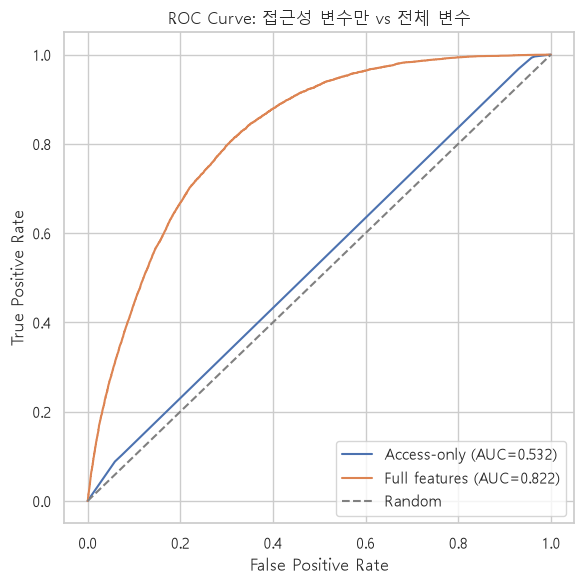

```python
fig, ax = plt.subplots(figsize=(6, 6))
for proba, auc, label in [(proba_a, auc_a, f"Access-only (AUC={auc_a:.3f})"),
                           (proba_b, auc_b, f"Full features (AUC={auc_b:.3f})")]:
    fpr, tpr, _ = roc_curve(y_test, proba)
    ax.plot(fpr, tpr, label=label)
ax.plot([0, 1], [0, 1], linestyle="--", color="gray", label="Random")
ax.set_xlabel("False Positive Rate")
ax.set_ylabel("True Positive Rate")
ax.set_title("ROC Curve: 접근성 변수만 vs 전체 변수")
ax.legend()
plt.tight_layout()
plt.show()
```

ROC 곡선은 판정 임계값을 1에서 0까지 훑으면서, 그때마다의 재현율(세로축)과 거짓 양성 비율(가로축)을 이어 그린 선이다. 대각선은 무작위 예측이고, 곡선이 왼쪽 위로 부풀수록 좋은 모델이며 그 아래 면적이 곧 ROC-AUC다.

Access-only 곡선은 대각선에 거의 붙어 있다 — 어떤 임계값을 잡아도 무작위보다 나은 판정을 하지 못한다는 뜻이다. 반면 Full 곡선은 뚜렷하게 위로 부풀어, 임계값을 조절하면 실용적인 지점을 찾을 수 있음을 보여준다. 아래에서 임계값 0.5를 잡았을 때 두 모델이 실제로 어떤 판정을 내리는지 확인한다.

```
=== Model A (access-only) classification report (threshold 0.5) ===
              precision    recall  f1-score   support

         0.0       0.93      0.07      0.13     54583
         1.0       0.14      0.97      0.25      8837

    accuracy                           0.19     63420
   macro avg       0.54      0.52      0.19     63420
weighted avg       0.82      0.19      0.15     63420

=== Model B (full features) classification report (threshold 0.5) ===
              precision    recall  f1-score   support

         0.0       0.95      0.73      0.82     54583
         1.0       0.31      0.76      0.44      8837

    accuracy                           0.73     63420
   macro avg       0.63      0.74      0.63     63420
weighted avg       0.86      0.73      0.77     63420
```

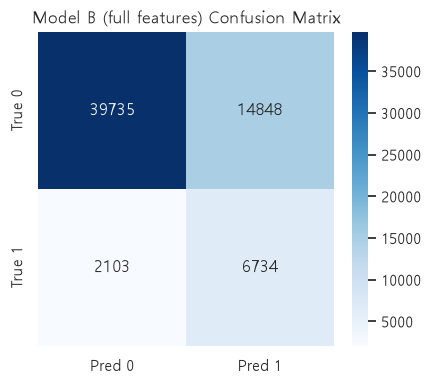

```python
print("=== Model A (access-only) classification report (threshold 0.5) ===")
print(classification_report(y_test, (proba_a >= 0.5).astype(int)))
print("=== Model B (full features) classification report (threshold 0.5) ===")
print(classification_report(y_test, (proba_b >= 0.5).astype(int)))

cm = confusion_matrix(y_test, (proba_b >= 0.5).astype(int))
fig, ax = plt.subplots(figsize=(4.5, 4))
sns.heatmap(cm, annot=True, fmt="d", cmap="Blues",
            xticklabels=["Pred 0", "Pred 1"], yticklabels=["True 0", "True 1"], ax=ax)
ax.set_title("Model B (full features) Confusion Matrix")
plt.tight_layout()
plt.show()
```

임계값 0.5에서 두 모델의 성격이 갈린다. Access-only 모델은 클래스 불균형을 보정하자 양성을 거의 다 "당뇨"로 예측해버려 재현율은 0.97까지 올라가지만 정밀도가 0.14에 불과하고, 그 결과 정확도가 19%까지 떨어진다 — 거의 모두를 환자로 지목하는 모델이라 실제로는 쓸 수 없다. 반면 Full 모델은 정확도 73%, 양성 재현율 0.76, 정밀도 0.31로 훨씬 균형 잡힌 판정을 하고, 혼동행렬에서도 실제 환자의 3/4가량을 잡아내는 것이 확인된다.

이는 앞선 로지스틱 회귀에서 확인한 것처럼 접근성 변수가 **통계적으로 유의한 독립 연관**은 갖고 있지만, 그 자체로는 당뇨를 예측하기엔 턱없이 부족한 신호라는 것을 명확히 보여준다. **"정책적으로 중요한 변수(접근성)"와 "예측에 유용한 변수"는 다르다**는 것이 이번 분석의 핵심 방법론적 교훈이다 — 그렇다면 실제 예측력은 어떤 변수에서 나오는지, 아래에서 Full 모델의 계수를 직접 확인한다.

### 8.1 Full 모델은 실제로 어떤 변수에 의존하는가

`StandardScaler`로 모든 변수를 표준화한 뒤 학습했기 때문에, 로지스틱 회귀 계수의 절댓값을 그대로 변수 간 상대적 중요도로 비교할 수 있다. 절댓값 상위 10개 변수를 확인한다.

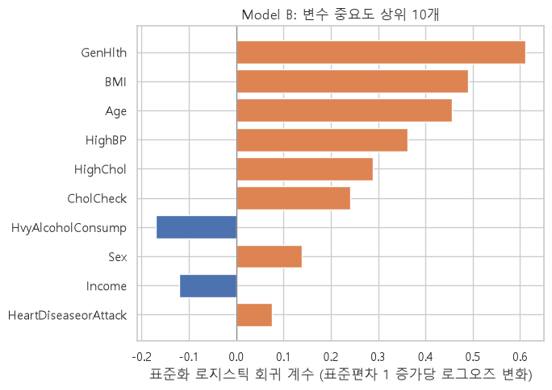

|  | feature | coef |
| --- | --- | --- |
| 13 | GenHlth | 0.611500 |
| 3 | BMI | 0.489508 |
| 18 | Age | 0.455666 |
| 0 | HighBP | 0.362842 |
| 1 | HighChol | 0.288923 |
| 2 | CholCheck | 0.240336 |
| 10 | HvyAlcoholConsump | -0.169488 |
| 17 | Sex | 0.139265 |
| 20 | Income | -0.120528 |
| 6 | HeartDiseaseorAttack | 0.074857 |

```python
feature_names = full_features
coefs = model_b.named_steps["clf"].coef_[0]
coef_df = pd.DataFrame({"feature": feature_names, "coef": coefs})
coef_df["abs_coef"] = coef_df["coef"].abs()
top_coef = coef_df.sort_values("abs_coef", ascending=False).head(10).iloc[::-1]

fig, ax = plt.subplots(figsize=(7, 5))
colors = ["#DD8452" if c > 0 else "#4C72B0" for c in top_coef["coef"]]
ax.barh(top_coef["feature"], top_coef["coef"], color=colors)
ax.axvline(0, color="gray", linewidth=0.8)
ax.set_xlabel("표준화 로지스틱 회귀 계수 (표준편차 1 증가당 로그오즈 변화)")
ax.set_title("Model B: 변수 중요도 상위 10개")
plt.tight_layout()
plt.show()

coef_df.sort_values("abs_coef", ascending=False).head(10)[["feature", "coef"]]
```

표준화 계수 상위권은 `GenHlth`(0.61), `BMI`(0.49), `Age`(0.46), `HighBP`(0.36), `HighChol`(0.29) 같은 임상·인구통계 지표가 차지한다 — 앞서 8절 도입부에서 예상한 그대로다. `CholCheck`(0.24)도 6위권에 들어 있는데, 크기가 작지 않은 이유는 실제 예측력이라기보다 7.2절에서 확인한 **검출편향**(검진을 받아야 진단이 기록되는 구조)이 예측 모델에도 그대로 반영된 것으로 봐야 한다. 반면 `NoDocbcCost`, `AnyHealthcare`는 상위 10개 안에 들지 못한다 — 오즈비로는 통계적으로 유의했지만, 21개 변수가 경쟁하는 예측 모델에서는 임상·인구통계 지표에 밀려 상대적 기여도가 작다는 뜻이다. **접근성 변수가 예측 모델에 거의 기여하지 못한다는 이전 절의 결론이 계수 크기로도 직접 확인된다.**

### 8.2 트리 기반 모델과의 비교

7절에서 "예측 성능이 더 좋을 수 있는 트리 기반 모델 대신 해석 가능한 로지스틱 회귀를 택했다"고 적었는데, 그 전제가 실제로 맞는지 — 즉 해석 가능성을 얻는 대가로 예측 성능을 얼마나 포기한 것인지 — 직접 확인한다.

비교 모델로는 `HistGradientBoostingClassifier`를 쓴다. sklearn 내장이라 새 의존성이 필요 없고, 히스토그램 기반이라 25만 행에서도 빠르며, `class_weight="balanced"`를 지원해 Model B와 **같은 분할·같은 클래스 가중치 조건**으로 맞출 수 있기 때문이다. 두 가지를 본다.

1. 전체 21개 변수 기준으로 트리 모델(Model C)이 로지스틱 회귀(Model B)보다 얼마나 나은가
2. 접근성 변수 3개만 줬을 때도 비선형 모델이라면 신호를 더 뽑아낼 수 있는가 — "접근성은 예측에 쓸 수 없다"는 앞 절의 결론이 모델 선택 탓은 아닌지 확인하는 검증

```python
from sklearn.ensemble import HistGradientBoostingClassifier


def build_tree_model():
    # Model B와 동일 조건(같은 분할, 같은 클래스 가중치, 같은 random_state)으로 맞춘다
    return HistGradientBoostingClassifier(class_weight="balanced", random_state=42)


model_c = build_tree_model().fit(X_train_f, y_train)
proba_c = model_c.predict_proba(X_test_f)[:, 1]
auc_c = roc_auc_score(y_test, proba_c)
cv_auc_c = cross_val_score(build_tree_model(), df[full_features], df[target], cv=cv, scoring="roc_auc")

# 검증 2: 접근성 변수 3개만 줬을 때도 트리 모델이 더 뽑아내는 게 있는지
model_c_access = build_tree_model().fit(X_train_a, y_train)
proba_c_access = model_c_access.predict_proba(X_test_a)[:, 1]
auc_c_access = roc_auc_score(y_test, proba_c_access)


def acc_at(proba):
    return ((proba >= 0.5).astype(int) == y_test).mean()


def recall_at(proba):
    return ((proba >= 0.5).astype(int) & (y_test == 1)).sum() / (y_test == 1).sum()


compare_model = pd.DataFrame({
    "ROC-AUC": [auc_a, auc_b, auc_c],
    "ROC-AUC(5-fold)": [cv_auc_a.mean(), cv_auc_b.mean(), cv_auc_c.mean()],
    "accuracy": [acc_at(proba_a), acc_at(proba_b), acc_at(proba_c)],
    "recall(양성)": [recall_at(proba_a), recall_at(proba_b), recall_at(proba_c)],
}, index=["Model A (access-only, 로지스틱)", "Model B (full, 로지스틱)", "Model C (full, 부스팅 트리)"])
print(compare_model.round(4))
print()
print(f"접근성 변수 3개만 쓴 경우 — 부스팅 트리 ROC-AUC {auc_c_access:.4f} vs 로지스틱 {auc_a:.4f}")
print(f"폴드별 ROC-AUC — Model B {np.round(cv_auc_b, 4)} / Model C {np.round(cv_auc_c, 4)}")
```

```
                             ROC-AUC  ROC-AUC(5-fold)  accuracy  recall(양성)
Model A (access-only, 로지스틱)   0.5317           0.5334    0.1946      0.9684
Model B (full, 로지스틱)          0.8219           0.8225    0.7327      0.7620
Model C (full, 부스팅 트리)        0.8295           0.8302    0.7213      0.7930

접근성 변수 3개만 쓴 경우 — 부스팅 트리 ROC-AUC 0.5317 vs 로지스틱 0.5317
폴드별 ROC-AUC — Model B [0.8269 0.8243 0.822  0.8223 0.8168] / Model C [0.8344 0.83   0.8306 0.8303 0.8257]
```

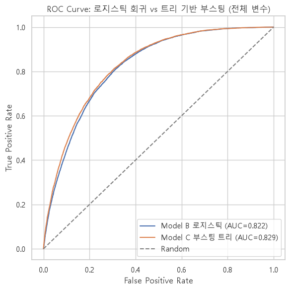

```python
fig, ax = plt.subplots(figsize=(6, 6))
for proba, label in [(proba_b, f"Model B 로지스틱 (AUC={auc_b:.3f})"),
                     (proba_c, f"Model C 부스팅 트리 (AUC={auc_c:.3f})")]:
    fpr, tpr, _ = roc_curve(y_test, proba)
    ax.plot(fpr, tpr, label=label)
ax.plot([0, 1], [0, 1], linestyle="--", color="gray", label="Random")
ax.set_xlabel("False Positive Rate")
ax.set_ylabel("True Positive Rate")
ax.set_title("ROC Curve: 로지스틱 회귀 vs 트리 기반 부스팅 (전체 변수)")
ax.legend()
plt.tight_layout()
plt.show()
```

트리 기반 부스팅(Model C)이 로지스틱 회귀(Model B)보다 실제로 낫긴 하지만, 그 차이는 ROC-AUC 0.8219 → 0.8295(5-fold 기준 0.8225 → 0.8302)로 0.008 남짓이다. 폴드별로 보면 5개 폴드 전부에서 Model C가 앞서므로 우연이라고 보기는 어렵지만, 크기 자체가 1%p에 못 미친다. 임계값 0.5에서는 재현율이 0.762 → 0.793으로 오르는 대신 정확도가 0.733 → 0.721로 내려가, 양성을 조금 더 적극적으로 잡는 쪽으로 움직였을 뿐 성격이 달라지지는 않았다.

차이가 이 정도에 그치는 이유는 데이터의 성격에 있다. `BMI`를 빼면 나머지 변수가 전부 이진 아니면 구간화된 순서형 코드(2절에서 확인)라, 트리 모델이 추가로 잡아낼 비선형성이나 상호작용의 여지가 애초에 크지 않다.

더 결정적인 것은 두 번째 검증이다. 접근성 변수 3개만 줬을 때 부스팅 트리의 ROC-AUC는 0.5317로, 로지스틱 회귀(0.5317)와 소수점 넷째 자리까지 같다. 세 변수가 모두 이진이라 만들 수 있는 조합이 8가지뿐이고 그 8개 그룹의 당뇨 비율이 어떤 모델이든 뽑아낼 수 있는 정보의 전부이기 때문이다. 즉 **"접근성 변수만으로는 당뇨를 예측할 수 없다"는 앞 절의 결론은 로지스틱 회귀를 골라서 생긴 결과가 아니라 데이터 자체의 성질**이며, 더 유연한 모델을 써도 달라지지 않는다.

정리하면, 7절에서 해석 가능성(오즈비·신뢰구간·p값)을 이유로 로지스틱 회귀를 택하면서 포기한 예측 성능은 ROC-AUC 0.008 정도다. 이 분석의 목적이 예측이 아니라 설명이라는 점을 감안하면 충분히 감수할 만한 대가이고, 반대로 예측 자체가 목적인 상황이라면 트리 기반 모델로 바꾸는 편이 낫다는 근거도 함께 확인한 셈이다.

## 9. 합성데이터 검증: 방법론이 실제로 작동하는가

지금까지 "교란변수를 통제하면 편향이 줄어든다", "`CholCheck`의 큰 오즈비는 검출편향일 것이다"라고 해석해왔다. 하지만 실제 데이터에는 '진짜 정답'이 없어서 이 해석이 맞는지 직접 증명할 수는 없었다. 여기서는 정답(진짜 효과 크기, 진짜 당뇨 여부)을 직접 정해놓은 합성데이터를 만들어, 지금까지 쓴 분석 방법이 그 정답을 실제로 잘 찾아내는지 검증한다.

### 9.1 실험 1 — 교란변수를 통제하면 정말 편향이 줄어드는가

`Income`(교란변수)이 `barrier`(접근성 장벽)와 `diabetes`(결과) 둘 다에 영향을 주도록 20만 명 규모의 가상 데이터를 만든다. `barrier`가 당뇨에 미치는 **"진짜" 오즈비를 1.3으로 미리 정해놓고** 시작한다 — 실제 데이터에서는 알 수 없는 값이지만, 합성데이터에서는 우리가 정한 값이므로 정답을 알고 있다.

```python
rng = np.random.default_rng(42)
n_sim = 200_000

sim_income = rng.uniform(1, 8, n_sim)                       # 소득 (교란변수)
p_barrier = 1 / (1 + np.exp((sim_income - 4.5) * 0.5))      # 소득 높을수록 접근성 장벽 확률 낮음
sim_barrier = rng.binomial(1, p_barrier)

TRUE_OR = 1.3                                                 # 우리가 정해놓은 '진짜' 오즈비
true_log_or = np.log(TRUE_OR)
income_coef = -0.30                                           # 소득 높을수록 당뇨 위험 낮음
logit_p = -1.6 + true_log_or * sim_barrier + income_coef * sim_income
p_diabetes = 1 / (1 + np.exp(-logit_p))
sim_diabetes = rng.binomial(1, p_diabetes)

sim1 = pd.DataFrame({"barrier": sim_barrier, "income": sim_income, "diabetes": sim_diabetes})

m_unadj = smf.logit("diabetes ~ barrier", data=sim1).fit(disp=0)
m_adj = smf.logit("diabetes ~ barrier + income", data=sim1).fit(disp=0)

result1 = pd.DataFrame({
    "odds_ratio": [TRUE_OR, np.exp(m_unadj.params["barrier"]), np.exp(m_adj.params["barrier"])]
}, index=["진짜 값(설계값)", "비보정 추정", "보정 추정(Income 통제)"])
result1.round(3)
```

|  | odds_ratio |
| --- | --- |
| 진짜 값(설계값) | 1.300 |
| 비보정 추정 | 2.142 |
| 보정 추정(Income 통제) | 1.289 |

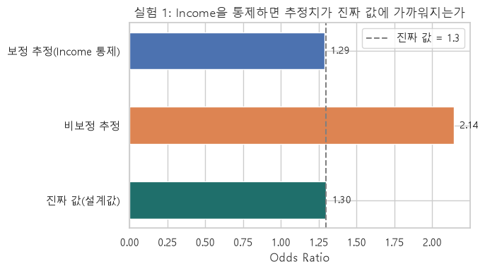

```python
fig, ax = plt.subplots(figsize=(7, 4))
labels1 = list(result1.index)
values1 = result1["odds_ratio"].values
bars1 = ax.barh(labels1, values1, color=["#1F6F6B", "#DD8452", "#4C72B0"], height=0.5)
for b, v in zip(bars1, values1):
    ax.annotate(f"{v:.2f}", (v, b.get_y() + b.get_height() / 2), textcoords="offset points",
                xytext=(6, 0), va="center", fontsize=10)
ax.axvline(TRUE_OR, color="gray", linestyle="--", label=f"진짜 값 = {TRUE_OR}")
ax.set_xlabel("Odds Ratio")
ax.set_title("실험 1: Income을 통제하면 추정치가 진짜 값에 가까워지는가")
ax.legend()
plt.tight_layout()
plt.show()
```

우리가 정해놓은 진짜 오즈비는 1.3인데, `Income`을 통제하지 않은 비보정 모델은 2.14로 실제보다 65% 넘게 부풀려서 추정한다. `Income`을 통제한 보정 모델은 1.29로 진짜 값(1.3)에 거의 정확히 들어맞는다. 실제 분석에서 관찰한 "비보정→보정으로 오즈비가 줄어드는 패턴"(예: `NoDocbcCost` 1.47→1.37)이 우연이 아니라, 교란변수를 통제하면 진짜 값에 더 가까워진다는 통계적 원리가 실제로 작동한다는 근거다.

### 9.2 실험 2 — 검출편향은 정말 오즈비를 부풀리는가

이번엔 `screening`(검진, `CholCheck`에 대응)이 **진짜 당뇨 여부와는 완전히 무관하도록**(진짜 인과효과 없음, OR=1) 설계한다. 대신 검진을 받은 사람은 실제 당뇨가 있을 때 95% 확률로 "진단"되고, 안 받은 사람은 40%만 진단되도록 — 즉 검진이 결과를 바꾸는 게 아니라 **발견 확률만 바꾸도록** 설계한다.

```python
rng2 = np.random.default_rng(7)
n_sim2 = 200_000

sim_true_diabetes = rng2.binomial(1, 0.14, n_sim2)
sim_screening = rng2.binomial(1, 0.96, n_sim2)               # 당뇨 위험과 완전 무관하게 무작위 배정
detect_prob = np.where(sim_screening == 1, 0.95, 0.40)        # 검진 여부에 따라 '발견 확률'만 다름
sim_diagnosed = np.where(sim_true_diabetes == 1, rng2.binomial(1, detect_prob), 0)

sim2 = pd.DataFrame({"screening": sim_screening, "true_diabetes": sim_true_diabetes, "diagnosed": sim_diagnosed})

m_true = smf.logit("true_diabetes ~ screening", data=sim2).fit(disp=0)
m_diag = smf.logit("diagnosed ~ screening", data=sim2).fit(disp=0)

result2 = pd.DataFrame({
    "odds_ratio": [np.exp(m_true.params["screening"]), np.exp(m_diag.params["screening"])]
}, index=["진짜 당뇨 기준(관찰 불가)", "진단 여부 기준(우리가 가진 데이터)"])
result2.round(3)
```

|  | odds_ratio |
| --- | --- |
| 진짜 당뇨 기준(관찰 불가) | 1.021 |
| 진단 여부 기준(우리가 가진 데이터) | 2.693 |

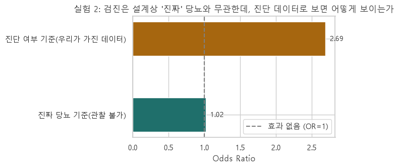

```python
fig, ax = plt.subplots(figsize=(7, 3.5))
labels2 = list(result2.index)
values2 = result2["odds_ratio"].values
bars2 = ax.barh(labels2, values2, color=["#1F6F6B", "#A6660F"], height=0.45)
for b, v in zip(bars2, values2):
    ax.annotate(f"{v:.2f}", (v, b.get_y() + b.get_height() / 2), textcoords="offset points",
                xytext=(6, 0), va="center", fontsize=10)
ax.axvline(1, color="gray", linestyle="--", label="효과 없음 (OR=1)")
ax.set_xlabel("Odds Ratio")
ax.set_title("실험 2: 검진은 설계상 '진짜' 당뇨와 무관한데, 진단 데이터로 보면 어떻게 보이는가")
ax.legend()
plt.tight_layout()
plt.show()
```

`screening`은 설계상 진짜 당뇨 여부와 완전히 무관하게 무작위로 배정했다(진짜 효과 오즈비=1이어야 정상). 실제로 "진짜 당뇨" 기준으로 보면 오즈비 1.02로 설계한 그대로 거의 정확히 재현된다. 그런데 우리가 실제로 관찰할 수 있는 건 "진단 여부"뿐이고, 검진을 받은 사람은 95%가 발견되는 반면 안 받은 사람은 40%만 발견되도록 설계했더니, 진단 여부 기준 오즈비는 2.69로 크게 부풀려진다. **아무 인과관계가 없어도 검진율 차이만으로 오즈비가 거의 3배 부풀려질 수 있다**는 걸 이 실험이 보여준다. 실제 분석에서 `CholCheck`의 오즈비가 5~6배로 나온 것도 정확히 이 메커니즘 때문일 가능성이 매우 높다는 근거다.

**두 실험이 말해주는 것**: 실험 1은 "왜 교란변수를 통제해야 하는가"를, 실험 2는 "왜 `CholCheck`의 큰 오즈비를 검출편향으로 의심해야 하는가"를 각각 정답을 아는 통제된 환경에서 증명한다. 합성데이터는 우리가 가정한 구조(로지스틱 관계, 특정 확률값)를 그대로 반영할 뿐이라 실제 세계를 완벽히 재현하지는 못하지만, 적어도 **이 분석 전체에서 쓴 통계적 논리 자체는 올바르게 작동한다**는 근거를 확인해준다.

## 10. 종합 결론 및 한계

### 결론

> **비용 때문에 진료를 못 받은 경험은 나쁜 건강 상태와 확실하게 함께 나타난다. 다만 그것이 원인인지는 이 데이터로 알 수 없다.**

연구 질문은 실제로 세 개이며, 답이 서로 다르다. 셋을 섞으면 결론이 정반대로 읽힌다.

| 질문 | 답 | 근거 |
| --- | --- | --- |
| 접근성과 건강 결과에 **연관**이 있는가 | **있다** — 세 지표 중 `NoDocbcCost` 하나 | 보정 후 당뇨 OR 1.37 (CI 1.31–1.43), 주관적 건강불량 OR 2.46 (CI 2.37–2.55) — 7절 |
| 접근성 지표로 개인의 당뇨를 **예측**할 수 있는가 | **없다** | 접근성 3개 모델 ROC-AUC 0.532, 부스팅 트리도 0.5317 — 8절 |
| 접근성이 건강 악화의 **원인**인가 | **알 수 없다** | 단면 데이터라 역인과 배제 불가 |

- **연관의 크기는 결과지표에 따라 다르다.** 당뇨는 OR 1.37로 작지만 주관적 건강은 2.46이고, 원자료 격차도 15.5% → 36.3%로 두 배가 넘는다. 의료비 부담이 특정 질환을 일으킨다기보다 전반적 건강 악화와 맞물려 있다고 읽는 편이 데이터에 맞다.
- **나머지 두 지표는 건강이 아니라 "진단이 기록되는 경로"를 측정한다.** `CholCheck`(OR 5.10)와 `AnyHealthcare`(OR 1.23)는 검진·의료 이용이 있어야 질환이 기록되는 구조에서 나온 검출편향이다. 9.2절에서 검진과 당뇨를 인과관계가 없도록 설계한 합성데이터에서도 발견 확률 차이만으로 오즈비가 1.02 → 2.69로 부풀려졌다. `CholCheck`를 빼자 `AnyHealthcare`가 1.33으로 커진 것은 편향이 사라진 게 아니라 옮겨간 것이다.
- **"예측할 수 없다"는 "영향이 없다"가 아니다.** 비용장벽 집단의 당뇨 유병률은 17.5%, 비경험 집단은 13.6%다(4절). 25만 명에서 이 차이는 명백하지만 양쪽 모두 대다수가 당뇨가 아니라 개인 분류 기준으로는 쓸모없고, 표본의 8.4%만 해당하는 이진 변수라 모델이 낼 수 있는 확률도 두 가지뿐이다. 같은 데이터로 21개 전체 변수를 쓰면 AUC 0.822가 나오므로, 한계는 당뇨의 예측 가능성이 아니라 접근성 지표의 정보량에 있다.
- **소득이 접근성과 건강 양쪽을 강하게 설명한다.** 소득이 낮을수록 비용장벽·건강불량·당뇨 유병률이 모두 단조 증가하며, 최하위군은 최상위군 대비 각각 7배·7.7배·3배다. 그래서 모든 모델에서 통제했다.

### 이 결론은 얼마나 견고한가

분석 선택을 바꿔가며 네 방향으로 점검했고, 모두 결론을 유지했다.

- **교란변수 선정(5절)** — 조정 후 오즈비 변화가 아니라 "노출·결과 양쪽과 연관됐는가"로 사전 선정. `BMI`는 매개 가능성이 있어 별도 위험요인으로 구분했다.
- **모델 가정(7.1절)** — VIF 1.02~1.35로 다중공선성 없음. `BMI` 비선형성은 존재하나 구간화 모델과 신뢰구간이 겹친다.
- **민감도 분석(7.2절)** — 검출편향이 의심되는 `CholCheck`를 빼도 `NoDocbcCost`는 1.37 → 1.34로 유지.
- **모델 선택·방법론(8.2절, 9절)** — 부스팅 트리로 바꿔도 결론이 같고, 정답을 아는 합성데이터에서 교란을 통제하니 추정치가 2.14 → 1.29로 진짜 값 1.3에 수렴했다.

### 한계

**데이터** — 표본가중치가 없어 전국 대표성을 보정할 수 없고, 인종·지역·가족력이 없어 소득 외 격차를 볼 수 없다(이들이 잔여 교란으로 남는다). 전 변수가 자가보고이며 `Diabetes_binary`는 유병이 아니라 "진단받은 적 있는지"를 묻기 때문에 접근성이 낮은 집단의 유병률이 과소추정된다 — 이 분석에서 다룬 검출편향이 여기서 비롯된다. 소득 최상위가 `75k+` 하나로 열려 있어 표본 35.6%가 한 칸에 몰려, 관찰된 소득 구배가 실제보다 완만할 수 있다. 2015년 자료이고, 중복행 9.5%는 구간화된 범주형 특성상 오류로 보기 어려워 유지했다.

**분석·해석** — **역인과가 가장 약한 고리다.** 단면 데이터라 "비용장벽 → 건강 악화"와 "건강 악화 → 의료 필요 증가 → 비용 부담"을 가릴 수 없고, OR 2.46은 후자로도 자연스럽게 설명되므로 인과로 읽어서는 안 된다(확인하려면 종단 데이터가 필요하다). 그 밖에 `BMI`가 매개변수라면 과잉보정으로 총효과가 과소추정됐을 수 있고, 교란을 피어슨 상관으로 스크리닝한 것도 한계다(교란은 상관의 크기가 아니라 인과 구조의 문제라 DAG를 함께 그렸다면 더 견고했다). 25만 행에서는 사소한 차이도 p<0.001이 되므로 판단은 유의성이 아니라 오즈비의 크기와 방향으로 해야 하며, 4절 카이제곱검정 12건은 다중비교 보정을 하지 않았다.

### 이 한계를 넘으려면 어떤 데이터가 필요한가

**같은 사람을 여러 시점에 추적하고, 건강 결과를 자가보고 대신 검사값으로 측정한 데이터가 필요하다.** 위 한계는 대부분 분석 기법이 아니라 자료 자체에서 비롯되므로, 같은 데이터에 더 복잡한 모델을 얹어서는 풀리지 않는다.

| 지금의 한계 | 필요한 데이터 | 해결되는 것 |
| --- | --- | --- |
| 단면 자료라 역인과를 못 가림 | **종단 패널** — 같은 사람의 반복 측정(예: MEPS) | t시점 비용장벽 → t+1시점 건강을 보고 t시점 건강을 통제해 시간 순서를 확보 |
| 진단 여부 자가보고 → 검출편향 | **검사 기반 결과지표** — HbA1c 실측치(예: NHANES) | 미진단 유병자가 포착되어 검출편향이 사라짐 |
| 표본가중치 없음 | 원 BRFSS 원자료의 복합표본 가중치 | 전국 대표성 보정 |
| 주(state)·연도 정보 없음 | 원 BRFSS 다년치(주 식별자 포함) | 2014년 메디케이드 확대의 주별 시행 시차를 준실험으로 활용(이중차분) |
| 인종·지역·가족력 없음 | 해당 변수를 포함한 조사 자료 | 소득 외 격차 분석, 잔여 교란 축소 |
| 소득 상단 개방(`75k+`에 35.6%) | 연속형 소득 또는 세분화된 상위 구간 | 고소득층 내부 구배 관찰 |

**우선순위는 위의 두 줄이다.** 종단성과 객관적 측정만 확보되면 이 분석의 결론은 "연관"에서 "인과"로 올라설 수 있고, 나머지는 정밀도 개선에 해당한다. 어느 것도 지금 데이터셋을 가공해서는 얻을 수 없고 자료 자체를 바꿔야 한다.

### 비즈니스 인사이트

> **접근성 지표는 "누구를 도울 것인가"를 정하는 데 쓰고, "누가 아플 것인가"를 맞히거나 사업 성과를 재는 데는 쓰지 않는다.**

아래 네 항목은 **누구에게(시장) → 무엇을(제품) → 하지 말 것(리스크) → 어떻게 잴 것(KPI)** 순서로, 하나의 사업 판단이 거치는 단계를 따라간다.

**1. 타깃 세그먼트가 데이터로 특정된다.** 비용 때문에 진료를 포기한 사람은 표본의 8.4%(21,354명)이며, 주관적 건강불량 오즈가 2.46배로 의료 수요는 큰데 가격 때문에 실현하지 못하고 있다. 저소득 구간에서 밀도가 두 배 이상 높다(연소득 15k 미만 두 구간 21.4%·18.7%, 6절). 저가 1차진료·원격진료·분할결제형 진료비 모델의 타깃이 된다.

**2. 검사 없이 문진만으로 위험 선별이 가능하다.** 전체 변수 모델은 ROC-AUC 0.822, 양성 재현율 76%이고, 예측력 대부분이 `GenHlth`·`BMI`·`Age`·`HighBP`·`HighChol` 등 앱에서 직접 답할 수 있는 항목에서 나온다(8.1절). 부스팅 트리로 올려도 0.830에 그치므로(8.2절) 초기 제품은 설명 가능하고 유지보수가 쉬운 로지스틱 회귀로 시작하는 편이 합리적이다.

**3. 접근성 데이터로 개인을 타깃팅해서는 안 된다.** 접근성 3개 모델의 ROC-AUC는 0.532, 부스팅 트리도 0.5317이다. 세 지표가 한쪽으로 크게 치우쳐(`AnyHealthcare` 95.1%·`CholCheck` 96.3%가 Yes, `NoDocbcCost` 91.6%가 No — 3.2절) 개인을 구분할 정보량 자체가 없다. 세그먼트 규모 추정에는 유효하지만 개인 단위 스코어링이나 타깃 마케팅에는 쓸 수 없다.

**4. 검진율을 KPI로 삼으면 사업이 성공할수록 지표가 나빠 보인다.** 검진을 늘리면 그동안 발견되지 않던 환자가 진단되며 유병률이 올라가기 때문이다. `CholCheck`의 오즈비 5.10이 그 구조이고, 9.2절은 인과가 전혀 없는 설계에서도 발견 확률 차이만으로 오즈비가 1.02 → 2.69가 됨을 보였다. 성과는 유병률 감소가 아니라 진단율과 관리 성과(치료 지속률·합병증 발생률)를 분리해 측정해야 한다.

**적용 전제** — 위는 연관에 기반한 것이지 인과의 증명이 아니다. 타깃 세그먼트의 존재와 규모는 인과 방향과 무관하게 유효하지만, "우리 서비스가 건강을 개선한다"는 효과 주장에는 쓸 수 없다(그러려면 도입 전후를 추적하는 자체 데이터가 필요하다). 2015년 미국 성인 설문이므로 다른 시장·시점에는 의료제도와 가격 구조 차이를 감안해야 한다.